# T.S Final Project

### 3.1.3 Model ARMA(3,2)+Garch(1,1) and assume residual is from standardized T distribution

```
##
## Title:
##  GARCH Modelling
##
## Call:
##  garchFit(formula = logrt.NZ50 ~ arma(3, 2) + garch(1, 1), data = logrt.NZ50,
##     cond.dist = "std", trace = FALSE)
##
## Mean and Variance Equation:
##  data ~ arma(3, 2) + garch(1, 1)
## <environment: 0x000001adfc9087d0>
##  [data = logrt.NZ50]
##
## Conditional Distribution:
##  std
##
## Coefficient(s):
##         mu         ar1         ar2         ar3         ma1         ma2
##  0.0046103   0.1559162   0.8287862  -0.0617834  -0.0790263  -0.8583566
##      omega      alpha1       beta1       shape
##  0.0119627   0.0738439   0.8991998   7.6635433
##
## Std. Errors:
##  based on Hessian
##
## Error Analysis:
##         Estimate  Std. Error  t value Pr(>|t|)
## mu      0.004610    0.002744    1.680  0.09293 .
## ar1     0.155916    0.086842    1.795  0.07259 .
## ar2     0.828786    0.091485    9.059  < 2e-16 ***
## ar3    -0.061783    0.022291   -2.772  0.00558 **
## ma1    -0.079026    0.083470   -0.947  0.34376
## ma2    -0.858357    0.081451  -10.538  < 2e-16 ***
## omega   0.011963    0.004168    2.870  0.00410 **
## alpha1  0.073844    0.014704    5.022 5.12e-07 ***
## beta1   0.899200    0.020952   42.917  < 2e-16 ***
## shape   7.663543    1.098767    6.975 3.07e-12 ***
## ---
## Signif. codes:  0 '***' 0.001 '**' 0.01 '*' 0.05 '.' 0.1 ' ' 1
##
## Log Likelihood:
##  -2306.363    normalized:  -0.9386905
##
## Description:
##  Mon Jan  2 16:31:08 2023 by user: User
##
##
## Standardised Residuals Tests:
##                                 Statistic p-Value
##  Jarque-Bera Test   R    Chi^2  307.521   0
##  Shapiro-Wilk Test  R    W      0.9868887 2.930205e-14
##  Ljung-Box Test     R    Q(10)  3.75918   0.9575575
##  Ljung-Box Test     R    Q(15)  10.16403  0.8092967
##  Ljung-Box Test     R    Q(20)  12.85809  0.8833893
##  Ljung-Box Test     R^2  Q(10)  8.419432  0.5879385
##  Ljung-Box Test     R^2  Q(15)  11.82445  0.6922651
##  Ljung-Box Test     R^2  Q(20)  13.48481  0.8556281
##  LM Arch Test       R    TR^2   9.914268  0.6234817
##
## Information Criterion Statistics:
##      AIC      BIC      SIC     HQIC
## 1.885521 1.909154 1.885488 1.894109
```

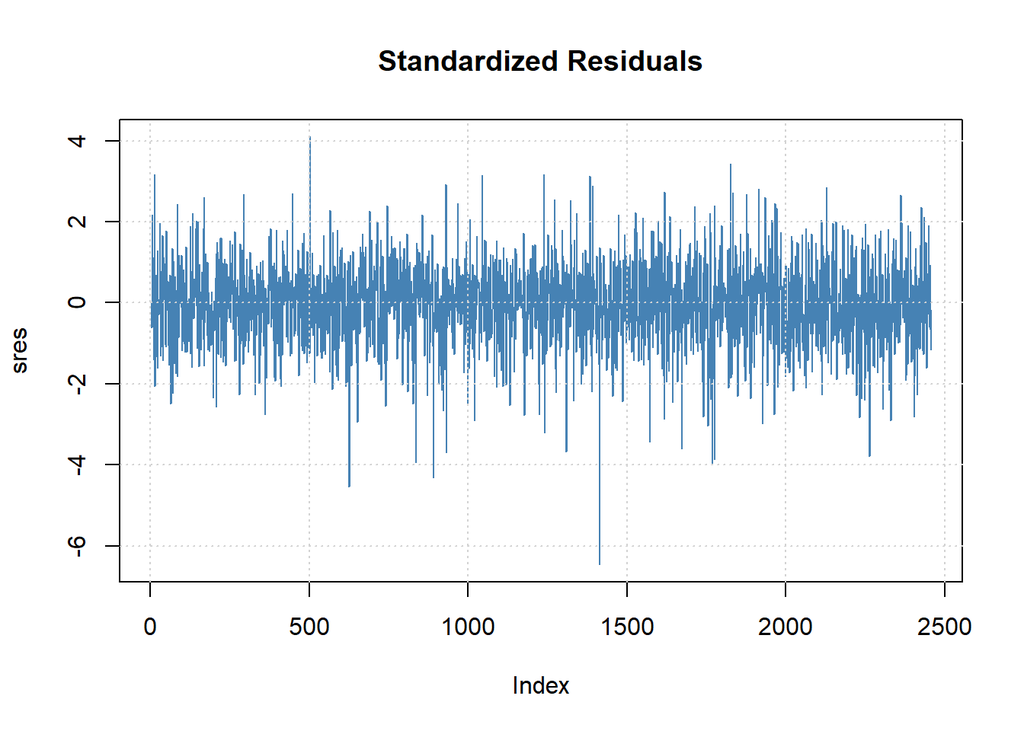

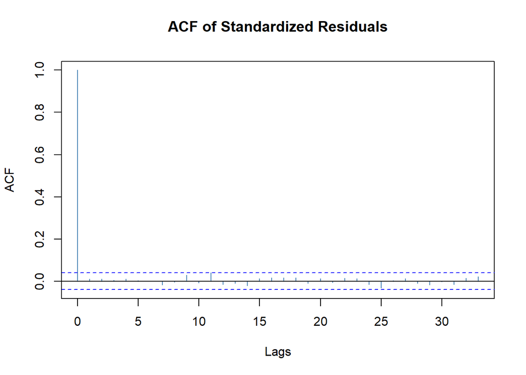

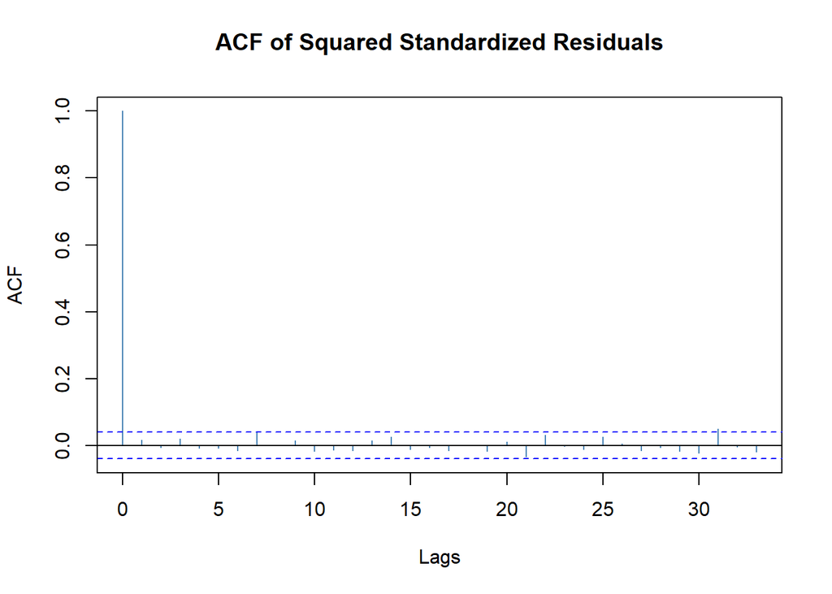

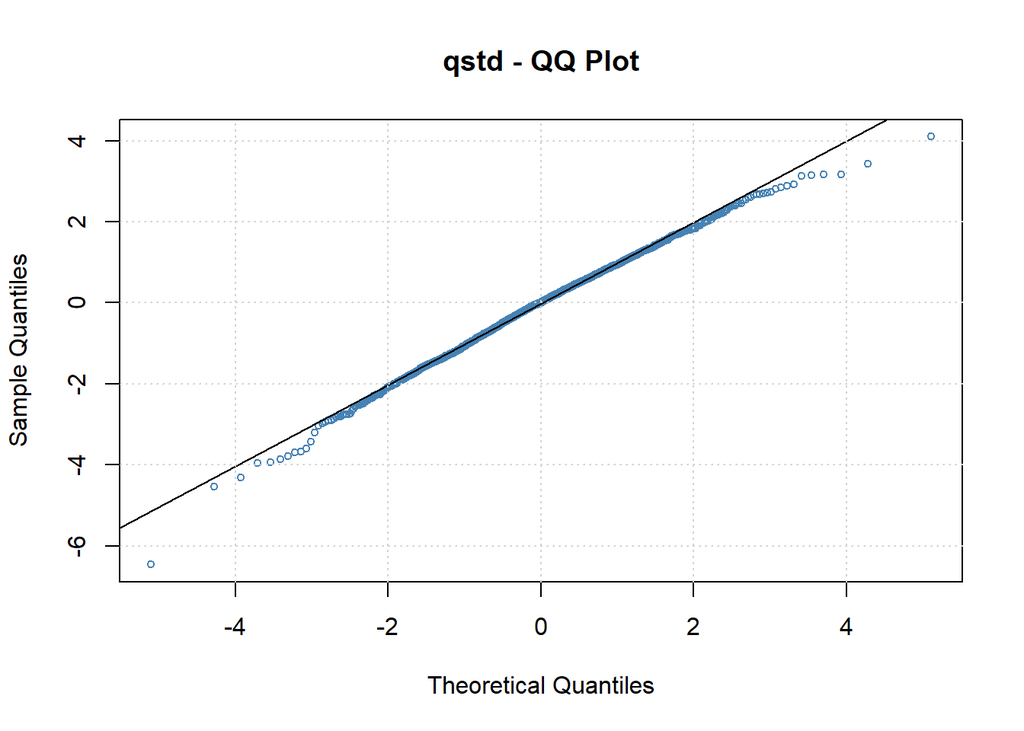

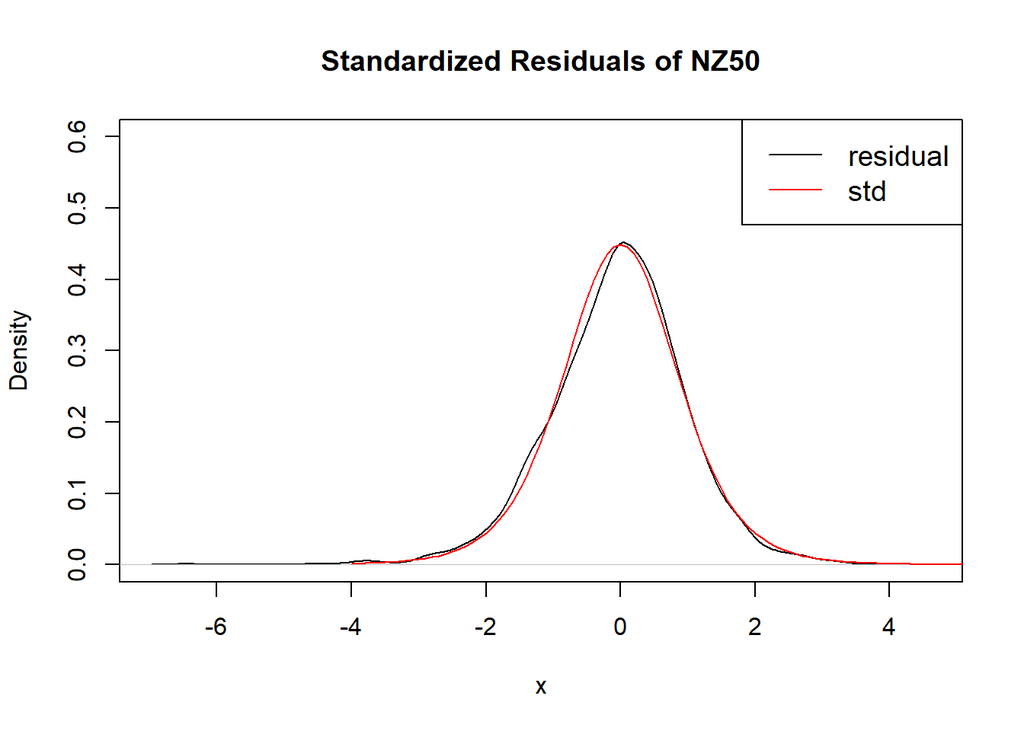

### 3.1.4 Model ARMA(3,1)+Garch(1,1) and assume residual is from standardized T distribution

```
##
## Title:
##  GARCH Modelling
##
## Call:
##  garchFit(formula = logrt.NZ50 ~ arma(3, 1) + garch(1, 1), data = logrt.NZ50,
##     cond.dist = "std", trace = FALSE)
##
## Mean and Variance Equation:
##  data ~ arma(3, 1) + garch(1, 1)
## <environment: 0x000001ad81240d10>
##  [data = logrt.NZ50]
##
## Conditional Distribution:
##  std
##
## Coefficient(s):
##         mu         ar1         ar2         ar3         ma1       omega
##  0.1094782  -0.7891711   0.0562996   0.0019748   0.8692633   0.0119774
##     alpha1       beta1       shape
##  0.0741545   0.8989834   7.6387088
##
## Std. Errors:
##  based on Hessian
##
## Error Analysis:
##         Estimate  Std. Error  t value Pr(>|t|)
## mu      0.109478    0.022102    4.953 7.29e-07 ***
## ar1    -0.789171    0.090550   -8.715  < 2e-16 ***
## ar2     0.056300    0.027319    2.061  0.03932 *
## ar3     0.001975    0.020446    0.097  0.92305
## ma1     0.869263    0.088187    9.857  < 2e-16 ***
## omega   0.011977    0.004153    2.884  0.00393 **
## alpha1  0.074155    0.014655    5.060 4.19e-07 ***
## beta1   0.898983    0.020811   43.198  < 2e-16 ***
## shape   7.638709    1.094126    6.982 2.92e-12 ***
## ---
## Signif. codes:  0 '***' 0.001 '**' 0.01 '*' 0.05 '.' 0.1 ' ' 1
##
## Log Likelihood:
##  -2309.292    normalized:  -0.9398829
##
## Description:
##  Mon Jan  2 16:31:10 2023 by user: User
##
##
## Standardised Residuals Tests:
##                                 Statistic p-Value
##  Jarque-Bera Test   R    Chi^2  298.2472  0
##  Shapiro-Wilk Test  R    W      0.9870724 3.86015e-14
##  Ljung-Box Test     R    Q(10)  4.001999  0.9472568
##  Ljung-Box Test     R    Q(15)  10.53858  0.7845652
##  Ljung-Box Test     R    Q(20)  12.28084  0.9060705
##  Ljung-Box Test     R^2  Q(10)  9.085805  0.5239802
##  Ljung-Box Test     R^2  Q(15)  13.01992  0.6007592
##  Ljung-Box Test     R^2  Q(20)  14.54896  0.8016085
##  LM Arch Test       R    TR^2   10.74212  0.5511389
##
## Information Criterion Statistics:
##      AIC      BIC      SIC     HQIC
## 1.887092 1.908362 1.887065 1.894821
```

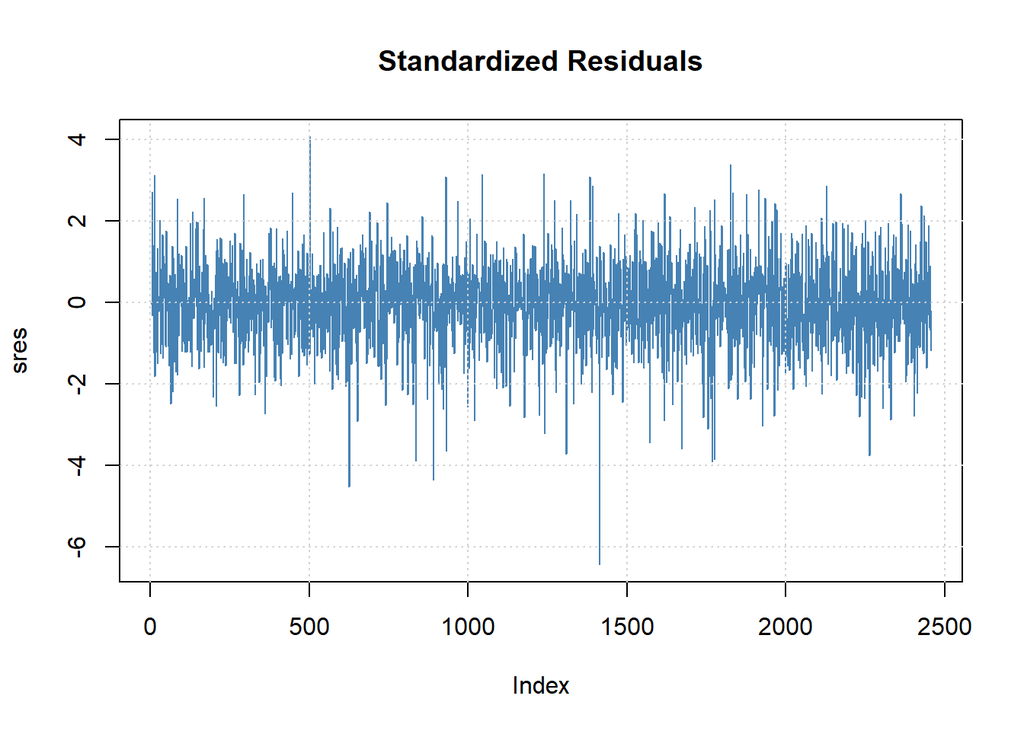

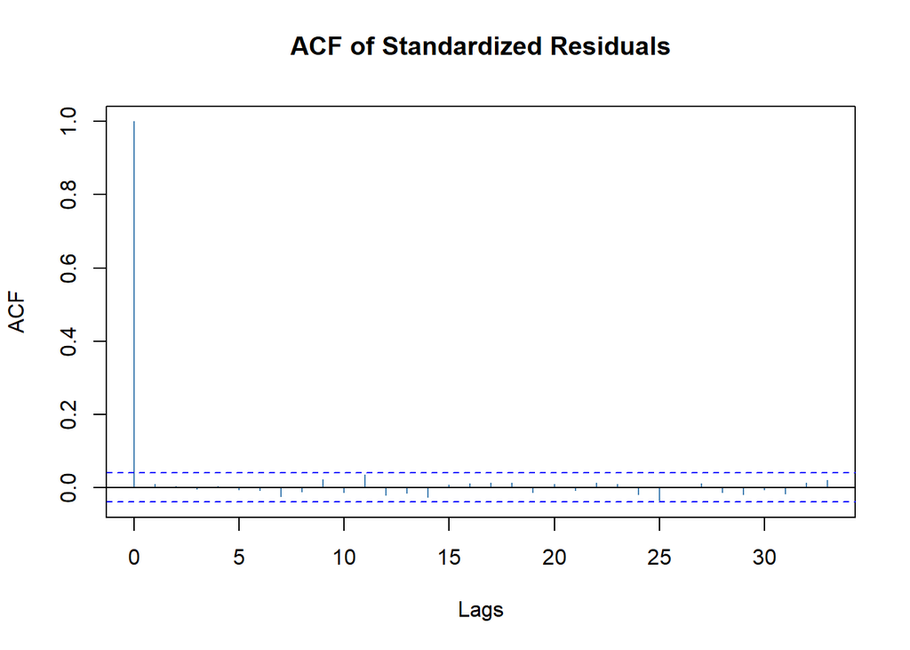

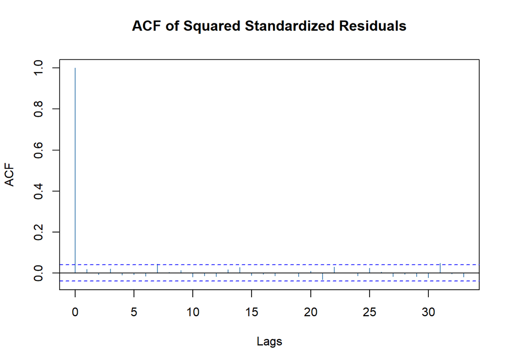

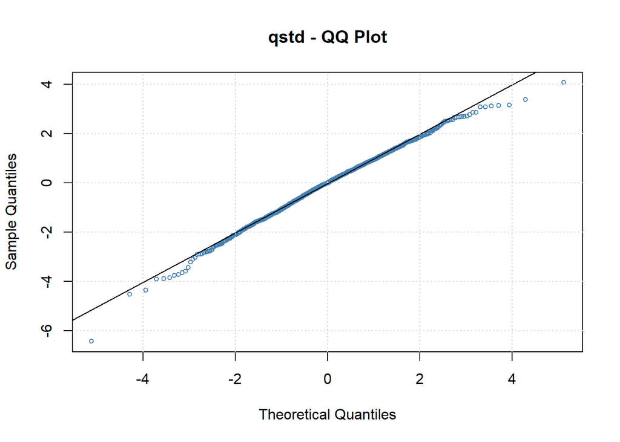

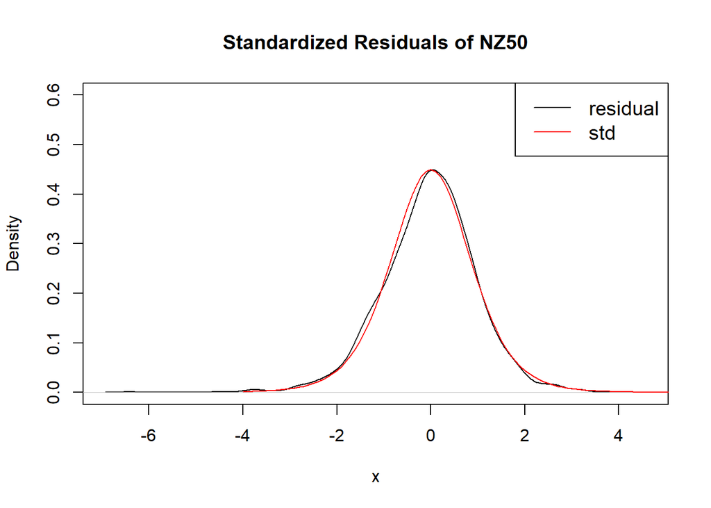

### 3.1.5 Model ARMA(2,1)+Garch(1,1) and assume residual is from standardized T distribution

```
##
## Title:
##  GARCH Modelling
##
## Call:
##  garchFit(formula = logrt.NZ50 ~ arma(2, 1) + garch(1, 1), data = logrt.NZ50,
##     cond.dist = "std", trace = FALSE)
##
## Mean and Variance Equation:
##  data ~ arma(2, 1) + garch(1, 1)
## <environment: 0x000001adfe49d030>
##  [data = logrt.NZ50]
##
## Conditional Distribution:
##  std
##
## Coefficient(s):
##        mu        ar1        ar2        ma1      omega     alpha1      beta1
##  0.111679  -0.821682   0.060340   0.902805   0.011999   0.074152   0.898867
##     shape
##  7.680446
##
## Std. Errors:
##  based on Hessian
##
## Error Analysis:
##         Estimate  Std. Error  t value Pr(>|t|)
## mu      0.111679    0.022040    5.067 4.04e-07 ***
## ar1    -0.821682    0.079483  -10.338  < 2e-16 ***
## ar2     0.060340    0.022927    2.632  0.00849 **
## ma1     0.902805    0.076096   11.864  < 2e-16 ***
## omega   0.011999    0.004156    2.887  0.00389 **
## alpha1  0.074152    0.014672    5.054 4.33e-07 ***
## beta1   0.898867    0.020848   43.116  < 2e-16 ***
## shape   7.680446    1.100749    6.977 3.01e-12 ***
## ---
## Signif. codes:  0 '***' 0.001 '**' 0.01 '*' 0.05 '.' 0.1 ' ' 1
##
## Log Likelihood:
##  -2309.36    normalized:  -0.9399106
##
## Description:
##  Mon Jan  2 16:31:11 2023 by user: User
##
##
## Standardised Residuals Tests:
##                                 Statistic p-Value
##  Jarque-Bera Test   R    Chi^2  298.8011  0
##  Shapiro-Wilk Test  R    W      0.9871125 4.100935e-14
##  Ljung-Box Test     R    Q(10)  3.690402  0.9602347
##  Ljung-Box Test     R    Q(15)  9.96209   0.8221178
##  Ljung-Box Test     R    Q(20)  11.75531  0.9242406
##  Ljung-Box Test     R^2  Q(10)  8.783851  0.5527325
##  Ljung-Box Test     R^2  Q(15)  12.77858  0.6193958
##  Ljung-Box Test     R^2  Q(20)  14.34536  0.8125624
##  LM Arch Test       R    TR^2   10.33273  0.5867952
##
## Information Criterion Statistics:
##      AIC      BIC      SIC     HQIC
## 1.886333 1.905240 1.886312 1.893203
```

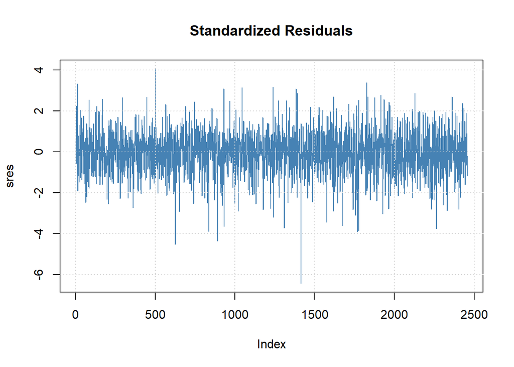

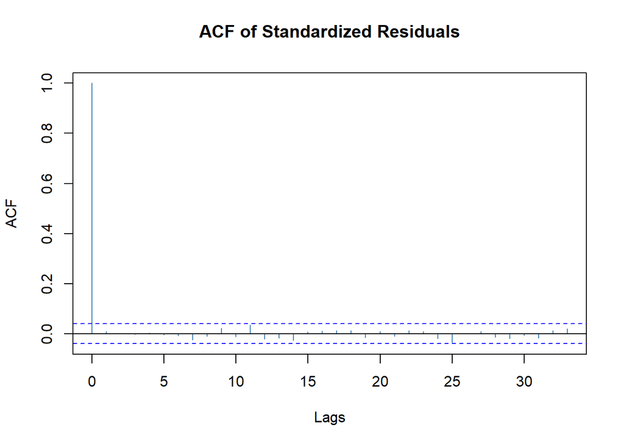

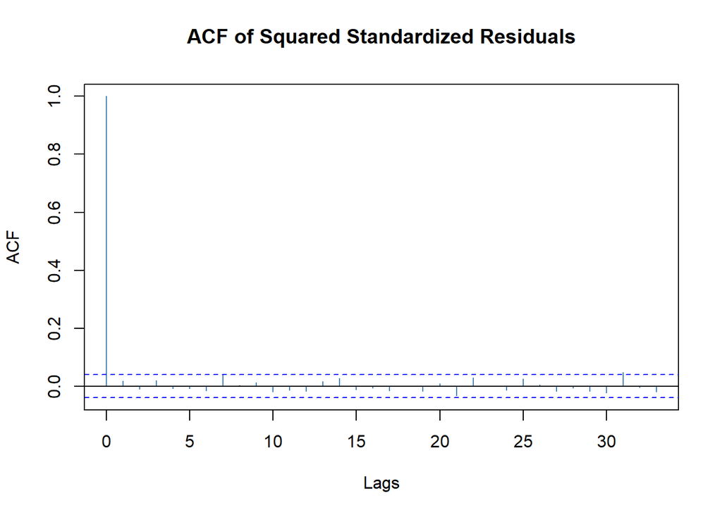

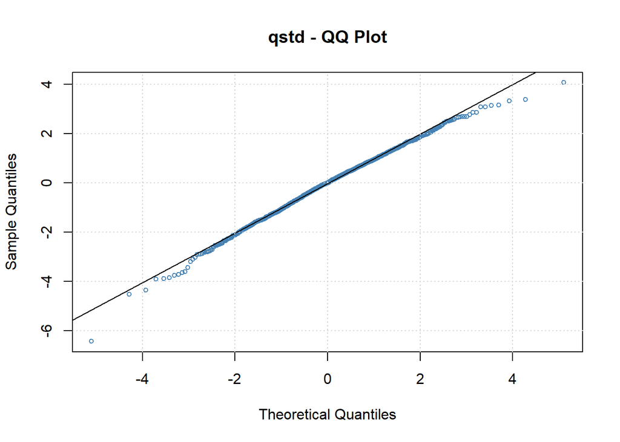

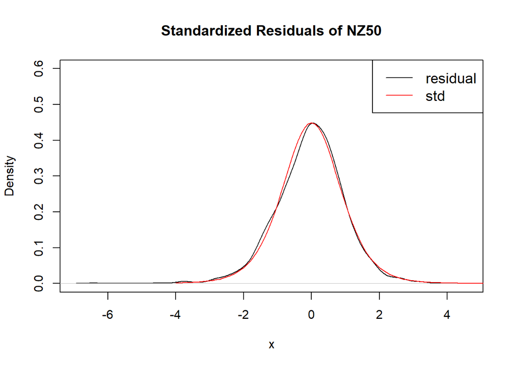

### 3.1.6 KS Test for residual

```
##
##  Asymptotic two-sample Kolmogorov-Smirnov test
##
## data:  res.NZ50 and sstd
## D = 0.033291, p-value = 0.4102
## alternative hypothesis: two-sided
```

## 3.2 USDNZD

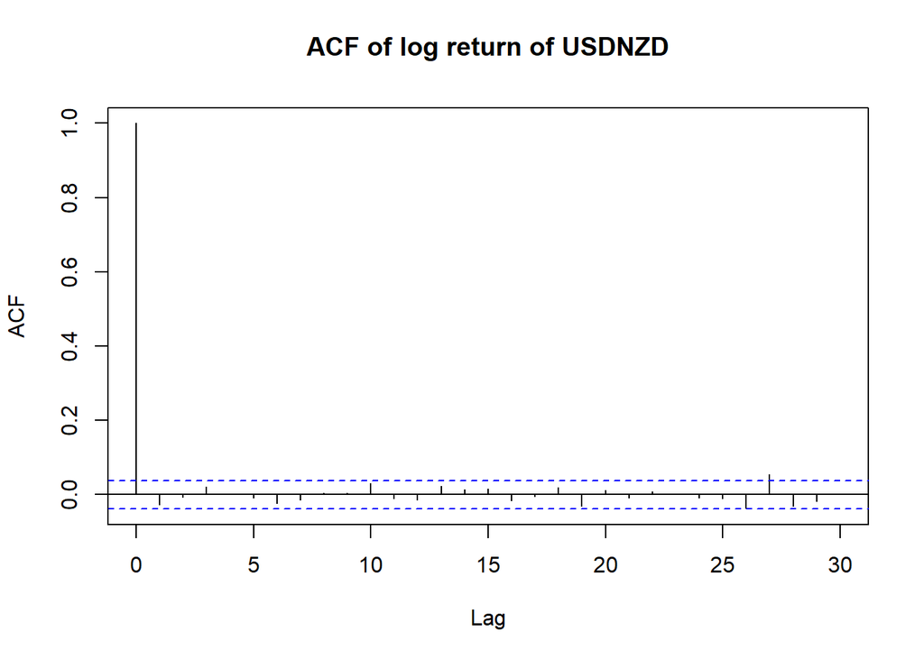

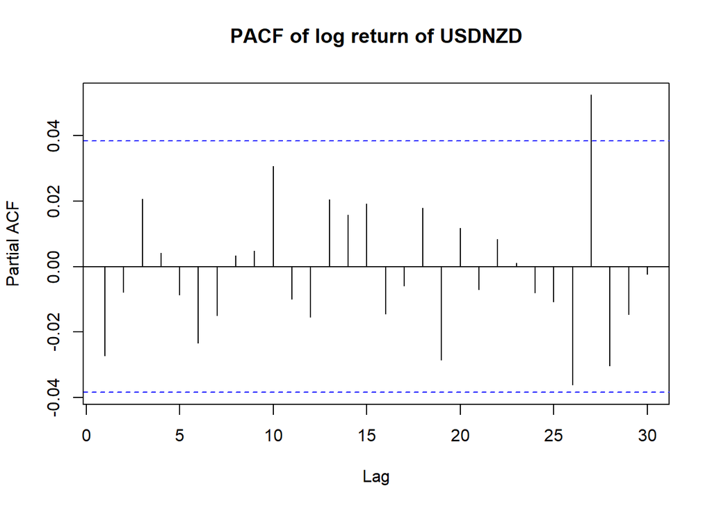

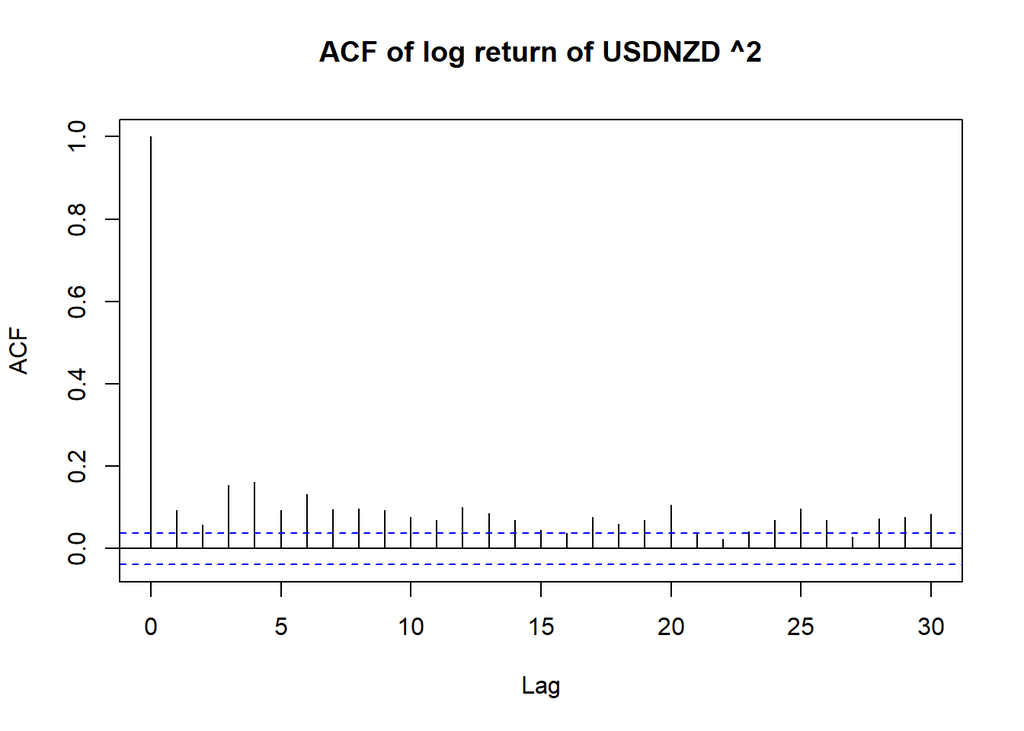

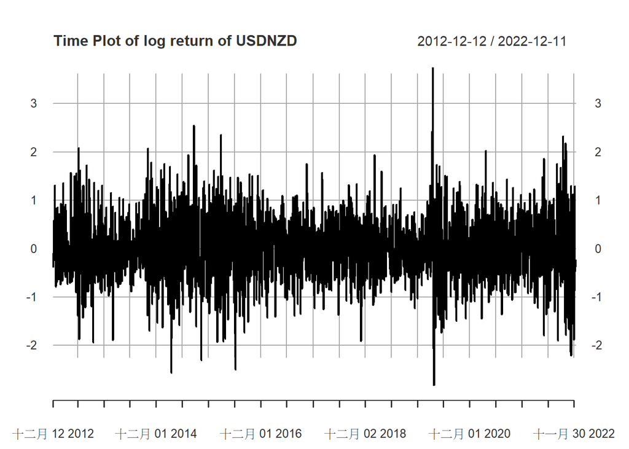

```
##
## Title:
##  Augmented Dickey-Fuller Test
##
## Test Results:
##   PARAMETER:
##     Lag Order: 1
##   STATISTIC:
##     Dickey-Fuller: -36.817
##   P VALUE:
##     0.01
##
## Description:
##  Mon Jan  2 16:31:12 2023 by user: User
```

```
##
##  Box-Ljung test
##
## data:  logrt.USDNZD
## X-squared = 7.6127, df = 10, p-value = 0.6666
```

```
##
##  Box-Ljung test
##
## data:  logrt.USDNZD^2
## X-squared = 316.5, df = 10, p-value < 2.2e-16
```

資料經過對數轉換與差分過後皆通過ADF Test，資料的一階動差也沒有序列相關，但二階動差有序列相關性故我們選擇從Garch(1,0)配適模型。

### 3.2.1 Model Garch(1,0) and residual diagnostic

```
##
## Title:
##  GARCH Modelling
##
## Call:
##  garchFit(formula = logrt.USDNZD ~ garch(1, 0), data = logrt.USDNZD,
##     trace = FALSE)
##
## Mean and Variance Equation:
##  data ~ garch(1, 0)
## <environment: 0x000001adfc954fc8>
##  [data = logrt.USDNZD]
##
## Conditional Distribution:
##  norm
##
## Coefficient(s):
##        mu      omega     alpha1
## 0.0097753  0.3897080  0.0971623
##
## Std. Errors:
##  based on Hessian
##
## Error Analysis:
##         Estimate  Std. Error  t value Pr(>|t|)
## mu      0.009775    0.012601    0.776    0.438
## omega   0.389708    0.013541   28.779  < 2e-16 ***
## alpha1  0.097162    0.023317    4.167 3.09e-05 ***
## ---
## Signif. codes:  0 '***' 0.001 '**' 0.01 '*' 0.05 '.' 0.1 ' ' 1
##
## Log Likelihood:
##  -2587.865    normalized:  -0.9938039
##
## Description:
##  Mon Jan  2 16:31:13 2023 by user: User
##
##
## Standardised Residuals Tests:
##                                 Statistic p-Value
##  Jarque-Bera Test   R    Chi^2  78.05776  0
##  Shapiro-Wilk Test  R    W      0.9945861 3.513917e-08
##  Ljung-Box Test     R    Q(10)  6.914035  0.7335349
##  Ljung-Box Test     R    Q(15)  10.57205  0.782299
##  Ljung-Box Test     R    Q(20)  14.96177  0.7785909
##  Ljung-Box Test     R^2  Q(10)  204.6881  0
##  Ljung-Box Test     R^2  Q(15)  259.96    0
##  Ljung-Box Test     R^2  Q(20)  322.5832  0
##  LM Arch Test       R    TR^2   150.7543  0
##
## Information Criterion Statistics:
##      AIC      BIC      SIC     HQIC
## 1.989912 1.996669 1.989909 1.992360
```

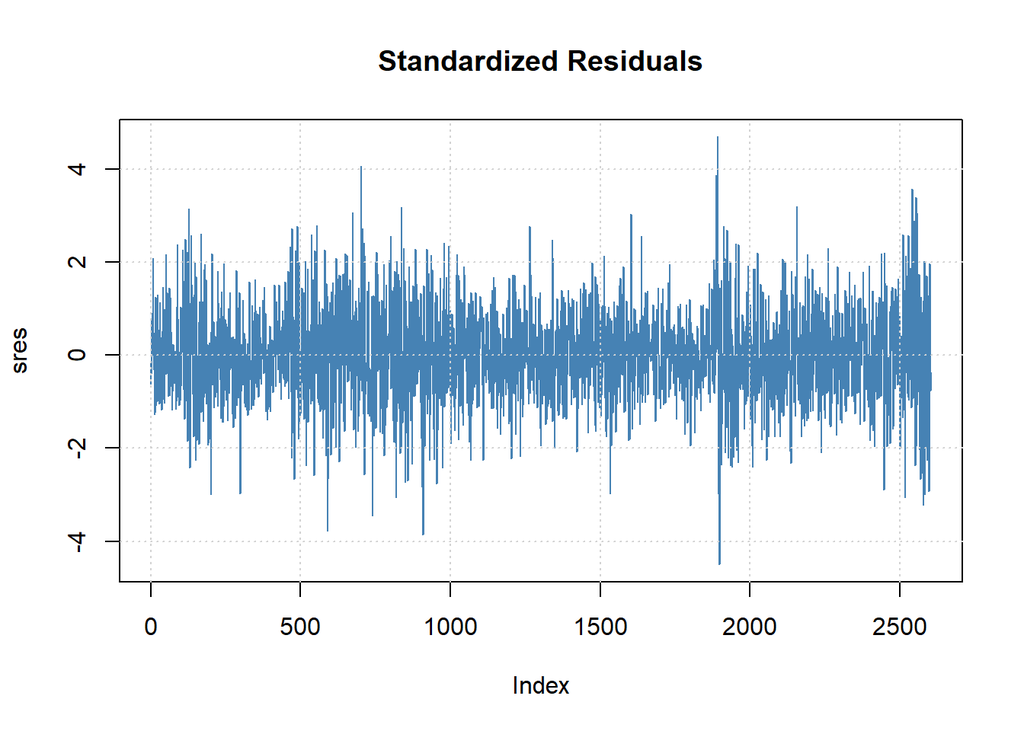

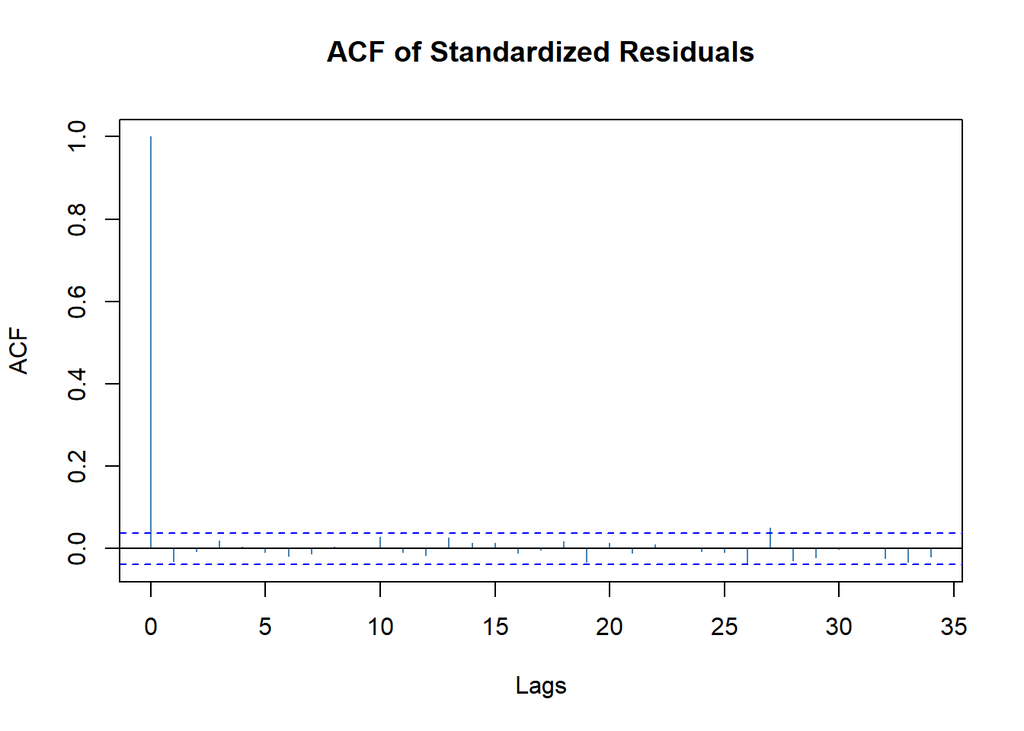

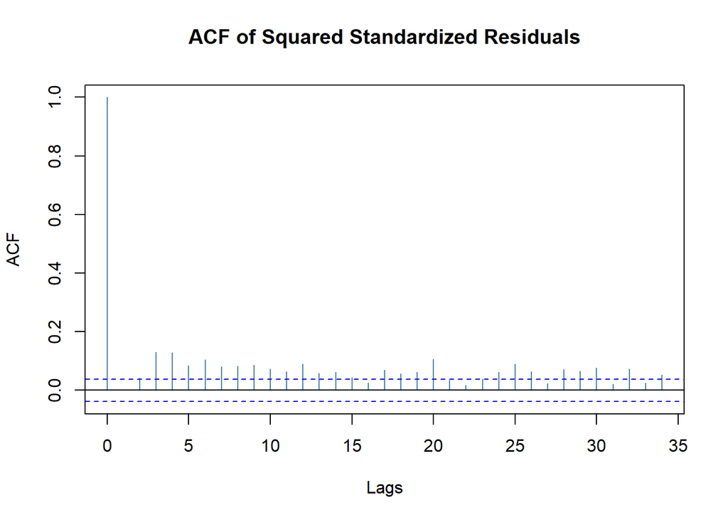

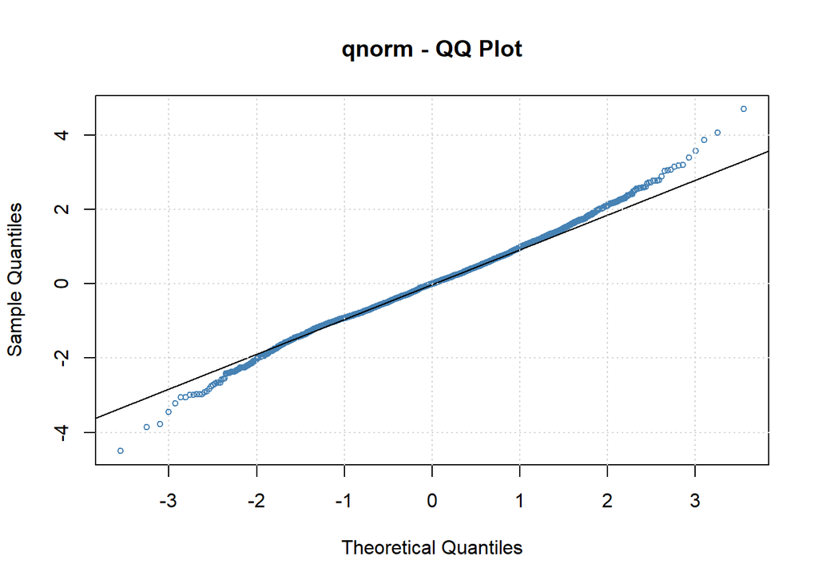

### 3.2.2 Model Garch(1,1) and residual diagnostic(assume residual is from standardize T distribution)

```
##
## Title:
##  GARCH Modelling
##
## Call:
##  garchFit(formula = logrt.USDNZD ~ garch(1, 1), data = logrt.USDNZD,
##     cond.dist = "std", trace = FALSE)
##
## Mean and Variance Equation:
##  data ~ garch(1, 1)
## <environment: 0x000001adfe495400>
##  [data = logrt.USDNZD]
##
## Conditional Distribution:
##  std
##
## Coefficient(s):
##         mu       omega      alpha1       beta1       shape
##  0.0077365   0.0037572   0.0390748   0.9540989  10.0000000
##
## Std. Errors:
##  based on Hessian
##
## Error Analysis:
##         Estimate  Std. Error  t value Pr(>|t|)
## mu      0.007737    0.011679    0.662   0.5077
## omega   0.003757    0.001698    2.213   0.0269 *
## alpha1  0.039075    0.007000    5.582 2.38e-08 ***
## beta1   0.954099    0.008625  110.622  < 2e-16 ***
## shape  10.000000    1.361981    7.342 2.10e-13 ***
## ---
## Signif. codes:  0 '***' 0.001 '**' 0.01 '*' 0.05 '.' 0.1 ' ' 1
##
## Log Likelihood:
##  -2493.22    normalized:  -0.9574579
##
## Description:
##  Mon Jan  2 16:31:14 2023 by user: User
##
##
## Standardised Residuals Tests:
##                                 Statistic p-Value
##  Jarque-Bera Test   R    Chi^2  39.73621  2.351752e-09
##  Shapiro-Wilk Test  R    W      0.9967995 2.665825e-05
##  Ljung-Box Test     R    Q(10)  7.047749  0.7209296
##  Ljung-Box Test     R    Q(15)  12.42745  0.6464287
##  Ljung-Box Test     R    Q(20)  14.77826  0.7889517
##  Ljung-Box Test     R^2  Q(10)  27.47057  0.002192998
##  Ljung-Box Test     R^2  Q(15)  31.43712  0.007673973
##  Ljung-Box Test     R^2  Q(20)  41.09336  0.003623743
##  LM Arch Test       R    TR^2   27.96376  0.005599977
##
## Information Criterion Statistics:
##      AIC      BIC      SIC     HQIC
## 1.918756 1.930017 1.918749 1.922836
```

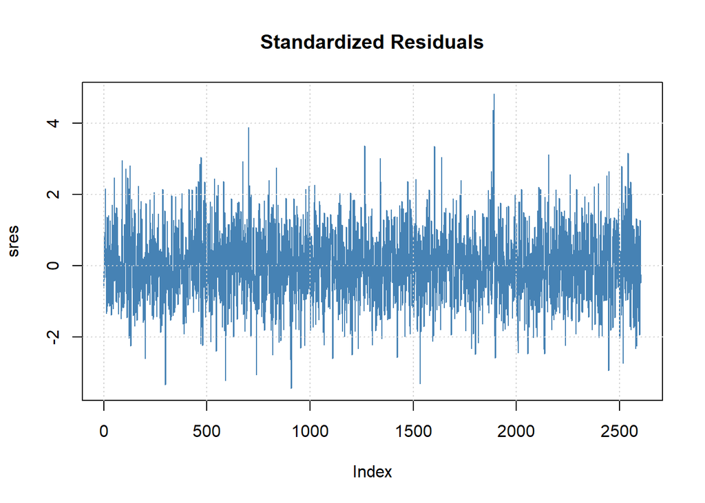

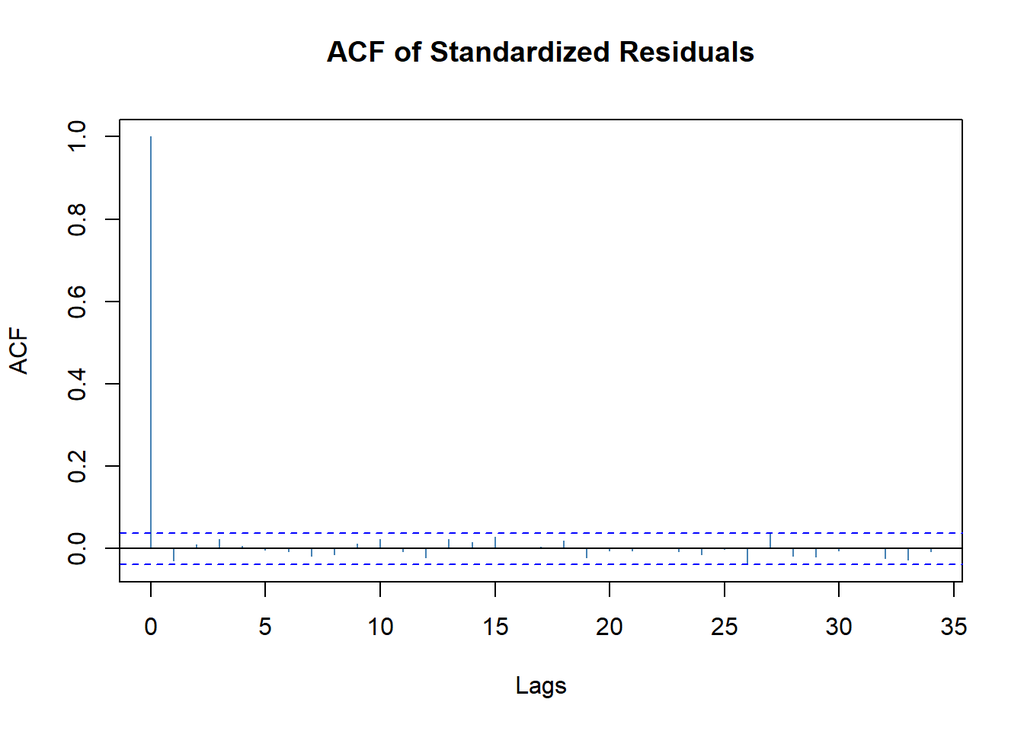

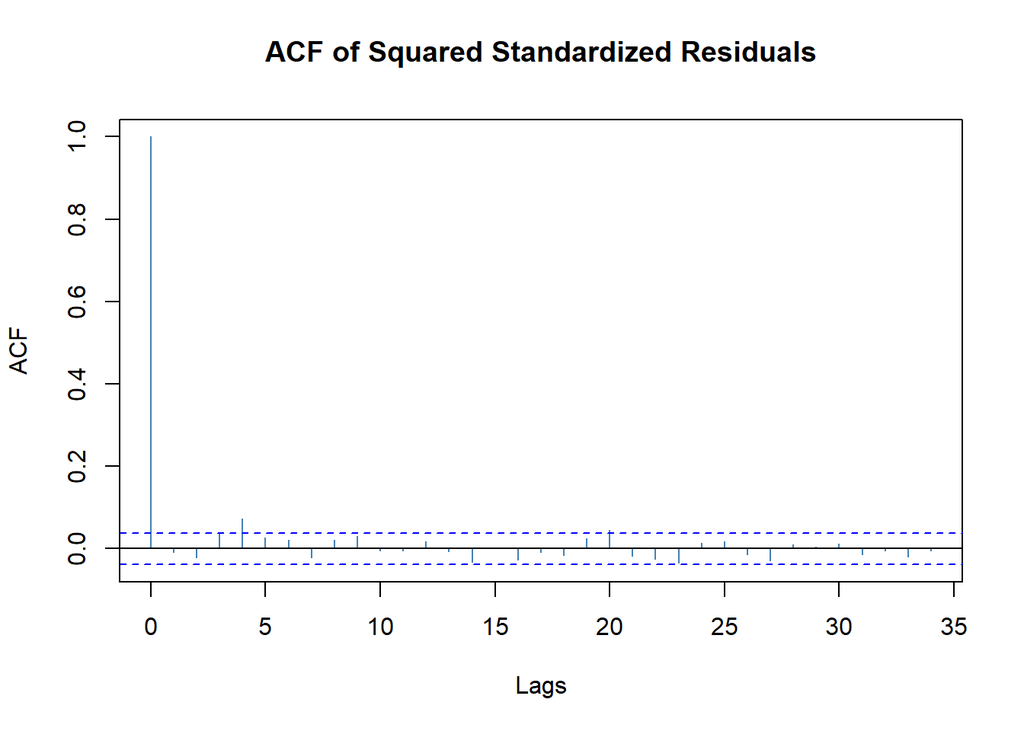

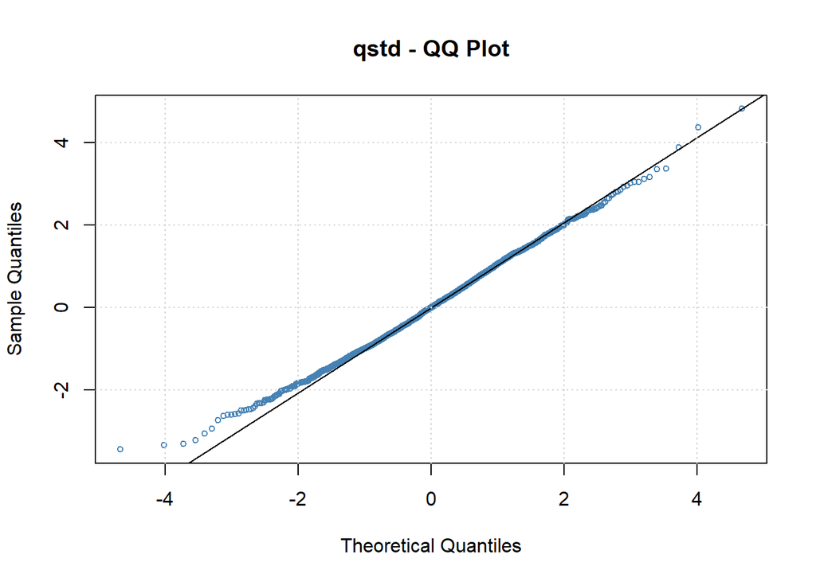

### 3.2.3 Model Garch(2,1) and residual diagnostic(assume residual is from standardize T distribution)

```
##
## Title:
##  GARCH Modelling
##
## Call:
##  garchFit(formula = logrt.USDNZD ~ garch(2, 1), data = logrt.USDNZD,
##     cond.dist = "std", trace = FALSE)
##
## Mean and Variance Equation:
##  data ~ garch(2, 1)
## <environment: 0x000001adfefdec80>
##  [data = logrt.USDNZD]
##
## Conditional Distribution:
##  std
##
## Coefficient(s):
##         mu       omega      alpha1      alpha2       beta1       shape
##  0.0078516   0.0042292   0.0168034   0.0257175   0.9497474  10.0000000
##
## Std. Errors:
##  based on Hessian
##
## Error Analysis:
##         Estimate  Std. Error  t value Pr(>|t|)
## mu      0.007852    0.011677    0.672   0.5013
## omega   0.004229    0.001924    2.198   0.0279 *
## alpha1  0.016803    0.020934    0.803   0.4222
## alpha2  0.025718    0.023131    1.112   0.2662
## beta1   0.949747    0.010244   92.713  < 2e-16 ***
## shape  10.000000    1.359851    7.354 1.93e-13 ***
## ---
## Signif. codes:  0 '***' 0.001 '**' 0.01 '*' 0.05 '.' 0.1 ' ' 1
##
## Log Likelihood:
##  -2492.717    normalized:  -0.9572644
##
## Description:
##  Mon Jan  2 16:31:14 2023 by user: User
##
##
## Standardised Residuals Tests:
##                                 Statistic p-Value
##  Jarque-Bera Test   R    Chi^2  40.55112  1.564721e-09
##  Shapiro-Wilk Test  R    W      0.9967643 2.364285e-05
##  Ljung-Box Test     R    Q(10)  7.122896  0.7137942
##  Ljung-Box Test     R    Q(15)  12.48742  0.6418236
##  Ljung-Box Test     R    Q(20)  14.82867  0.7861259
##  Ljung-Box Test     R^2  Q(10)  26.46047  0.003167826
##  Ljung-Box Test     R^2  Q(15)  30.67187  0.009716574
##  Ljung-Box Test     R^2  Q(20)  40.07068  0.00489363
##  LM Arch Test       R    TR^2   26.36295  0.009533202
##
## Information Criterion Statistics:
##      AIC      BIC      SIC     HQIC
## 1.919137 1.932651 1.919127 1.924033
```

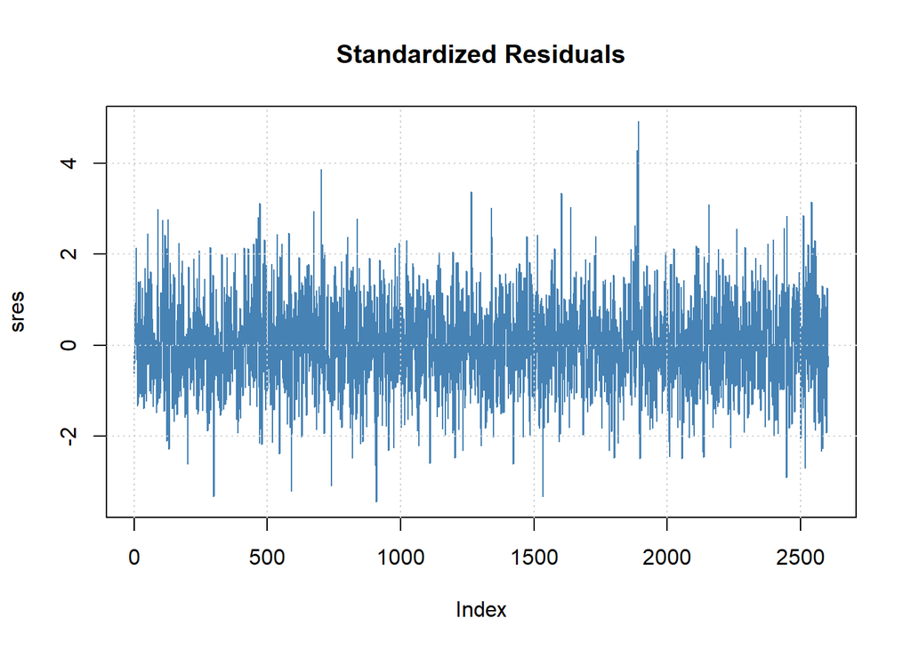

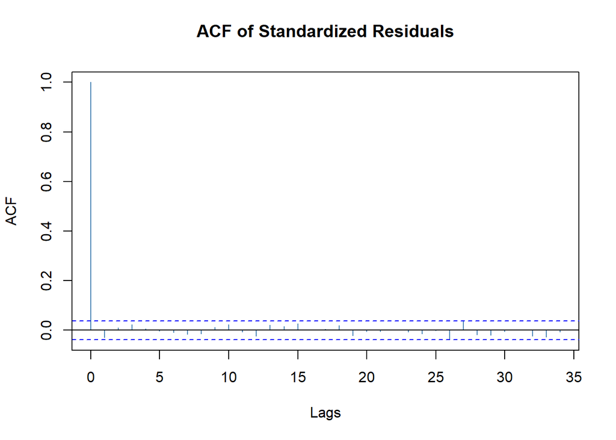

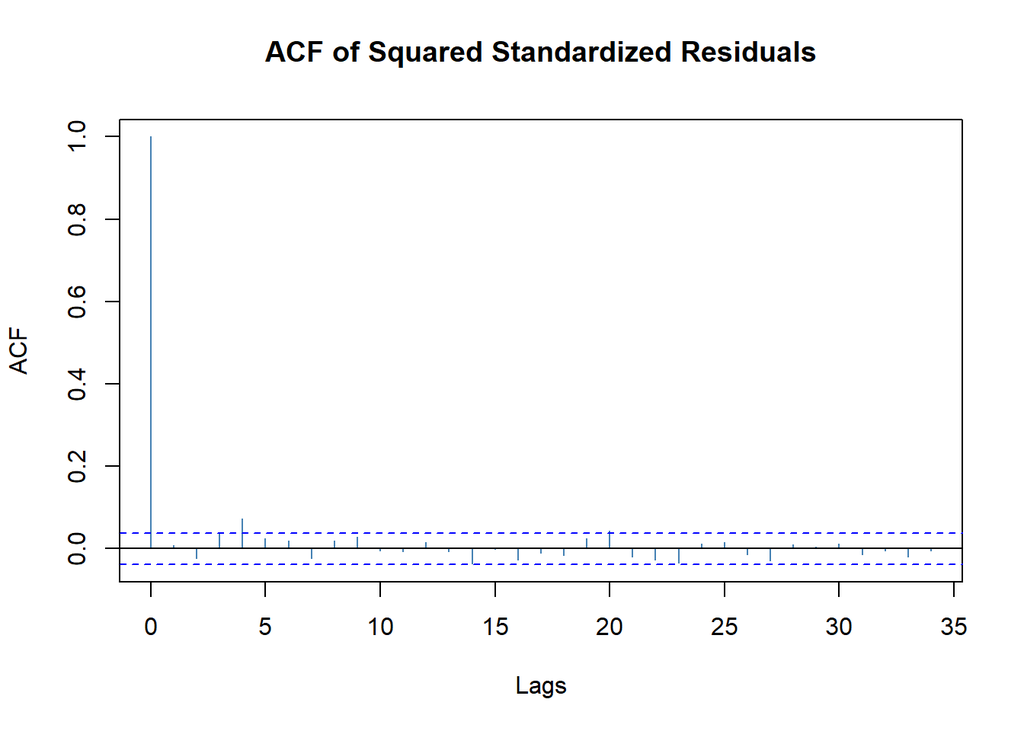

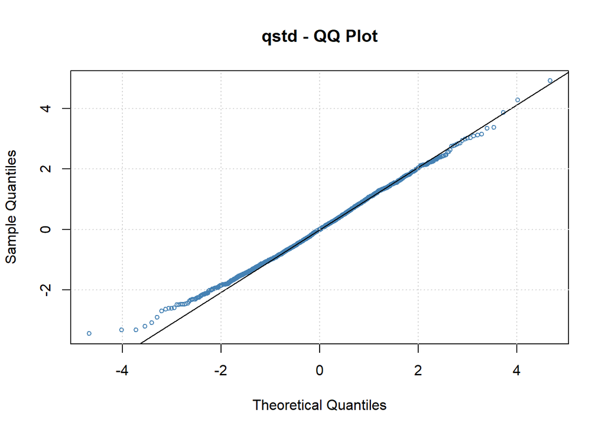

由於Garch(2,1)的係數不如Garch(1,1)的模型顯著，雖然殘差的一階動差無序列相關，但殘差的二階動差具有序列相關性，故我們將資料逐年檢查，去除有問題的年份後重新配適Garch(1,1)。

### 3.2.4 Refit Model Garch(1,1) and residual diagnostic since 2013-10-12 to 2017-10-12

```
## [1] "USDNZD=X"
```

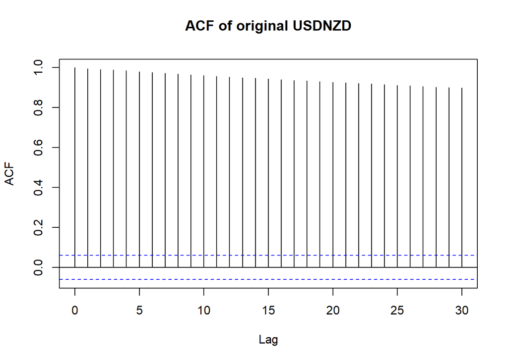

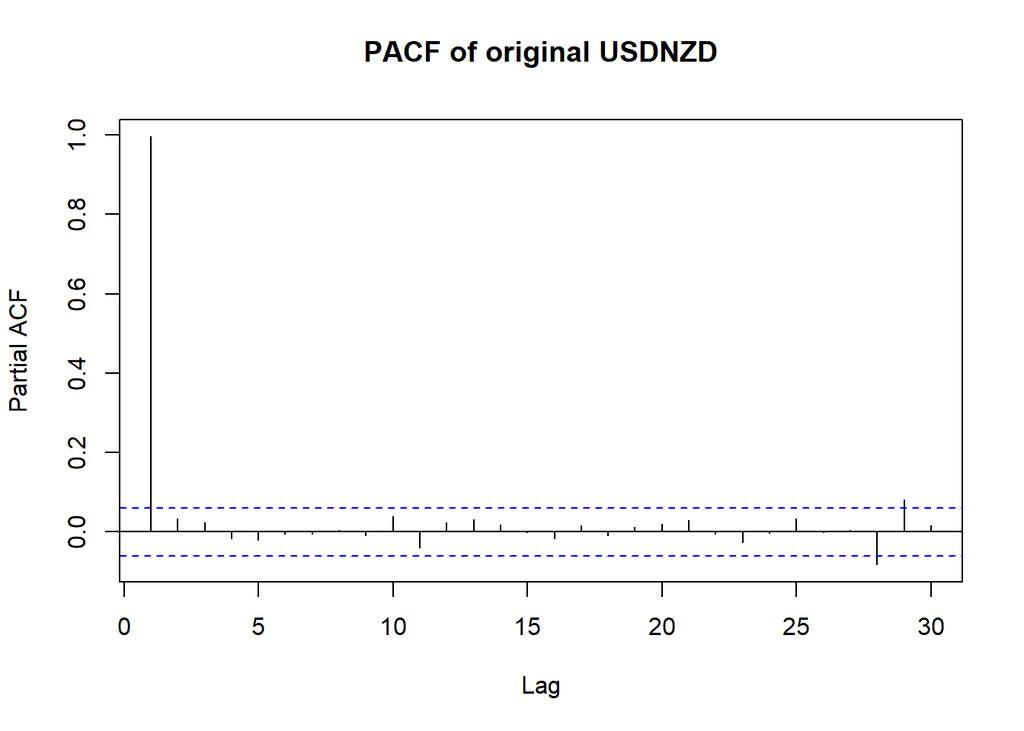

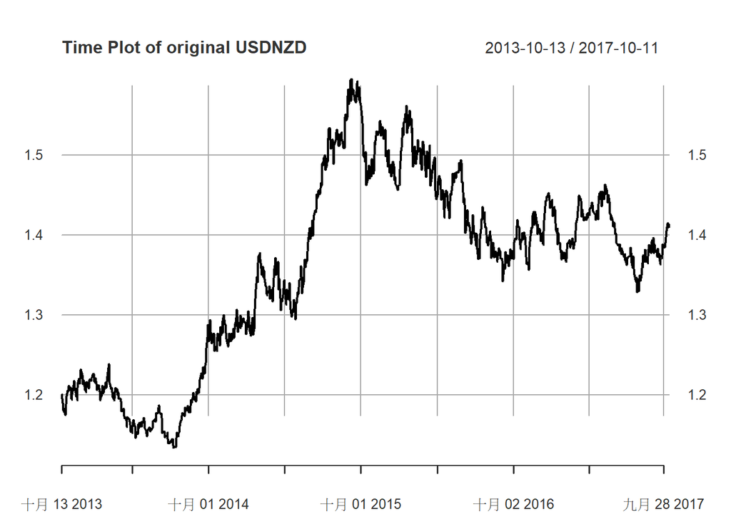

```
##
##  Box-Ljung test
##
## data:  USDNZD
## X-squared = 10067, df = 10, p-value < 2.2e-16
```

```
##
## Title:
##  Augmented Dickey-Fuller Test
##
## Test Results:
##   PARAMETER:
##     Lag Order: 1
##   STATISTIC:
##     Dickey-Fuller: -1.4825
##   P VALUE:
##     0.7974
##
## Description:
##  Mon Jan  2 16:31:16 2023 by user: User
```

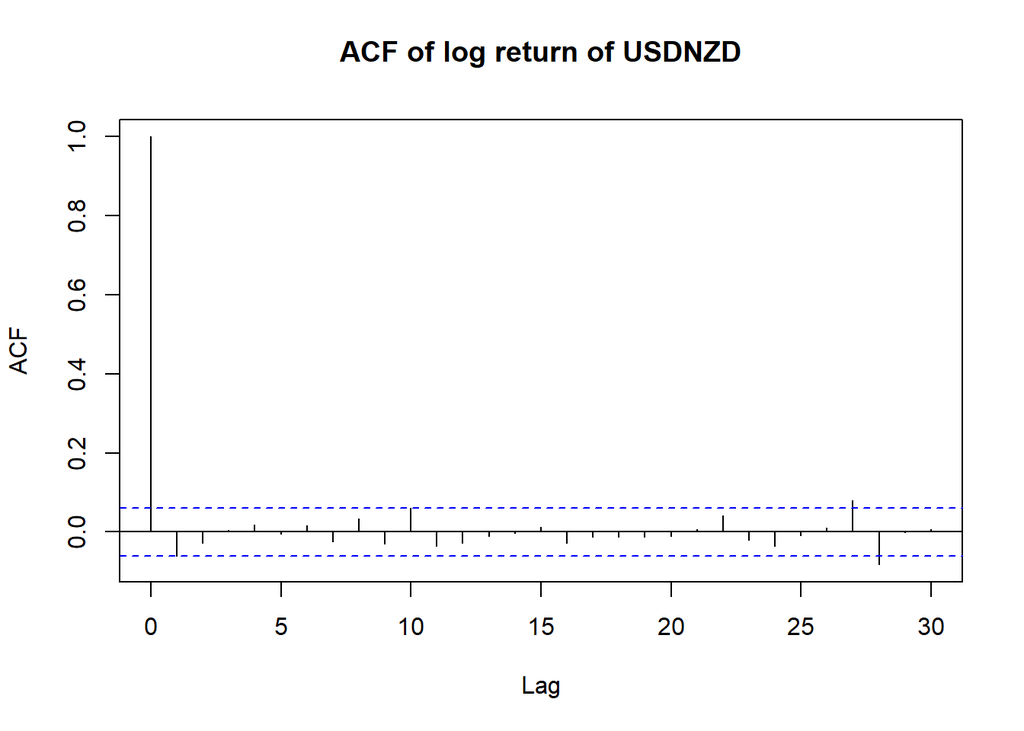

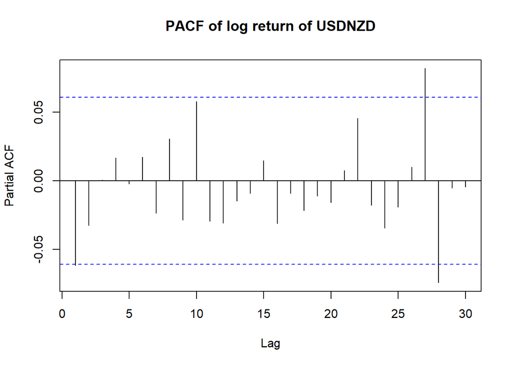

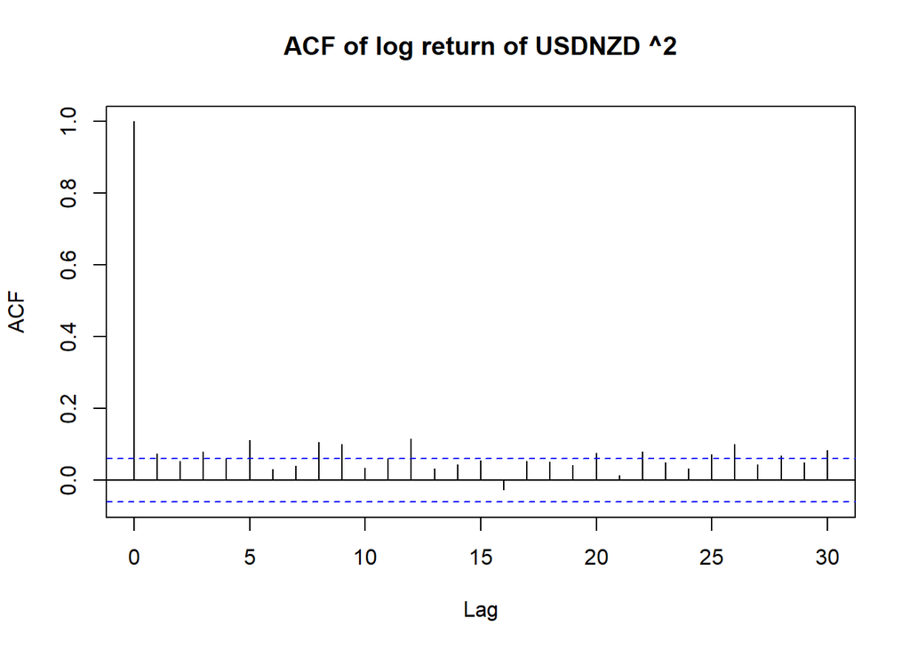

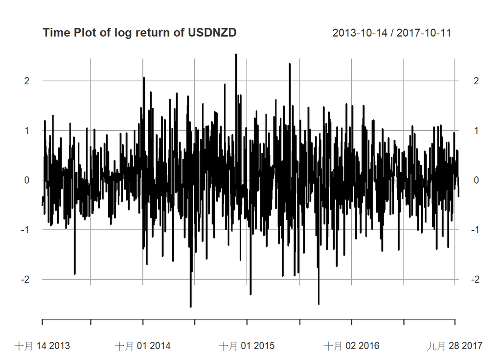

```
##
## Title:
##  Augmented Dickey-Fuller Test
##
## Test Results:
##   PARAMETER:
##     Lag Order: 1
##   STATISTIC:
##     Dickey-Fuller: -24.2662
##   P VALUE:
##     0.01
##
## Description:
##  Mon Jan  2 16:31:16 2023 by user: User
```

```
##
##  Box-Ljung test
##
## data:  logrt.USDNZD
## X-squared = 12.017, df = 10, p-value = 0.2839
```

```
##
##  Box-Ljung test
##
## data:  logrt.USDNZD^2
## X-squared = 58.112, df = 10, p-value = 8.235e-09
```

```
##
## Title:
##  GARCH Modelling
##
## Call:
##  garchFit(formula = logrt.USDNZD ~ garch(1, 1), data = logrt.USDNZD,
##     trace = FALSE)
##
## Mean and Variance Equation:
##  data ~ garch(1, 1)
## <environment: 0x000001adfdcfb970>
##  [data = logrt.USDNZD]
##
## Conditional Distribution:
##  norm
##
## Coefficient(s):
##        mu      omega     alpha1      beta1
## 0.0133319  0.0024097  0.0355840  0.9592831
##
## Std. Errors:
##  based on Hessian
##
## Error Analysis:
##         Estimate  Std. Error  t value Pr(>|t|)
## mu      0.013332    0.019175    0.695 0.486873
## omega   0.002410    0.001775    1.357 0.174668
## alpha1  0.035584    0.009295    3.828 0.000129 ***
## beta1   0.959283    0.010616   90.363  < 2e-16 ***
## ---
## Signif. codes:  0 '***' 0.001 '**' 0.01 '*' 0.05 '.' 0.1 ' ' 1
##
## Log Likelihood:
##  -1034.92    normalized:  -0.9932058
##
## Description:
##  Mon Jan  2 16:31:16 2023 by user: User
##
##
## Standardised Residuals Tests:
##                                 Statistic p-Value
##  Jarque-Bera Test   R    Chi^2  4.292762  0.1169065
##  Shapiro-Wilk Test  R    W      0.9982634 0.3750071
##  Ljung-Box Test     R    Q(10)  10.50946  0.3969885
##  Ljung-Box Test     R    Q(15)  12.86118  0.6130197
##  Ljung-Box Test     R    Q(20)  13.85331  0.8378549
##  Ljung-Box Test     R^2  Q(10)  10.30443  0.4142026
##  Ljung-Box Test     R^2  Q(15)  16.72771  0.3354007
##  Ljung-Box Test     R^2  Q(20)  27.72943  0.1159606
##  LM Arch Test       R    TR^2   13.41283  0.3397616
##
## Information Criterion Statistics:
##      AIC      BIC      SIC     HQIC
## 1.994089 2.013087 1.994060 2.001295
```

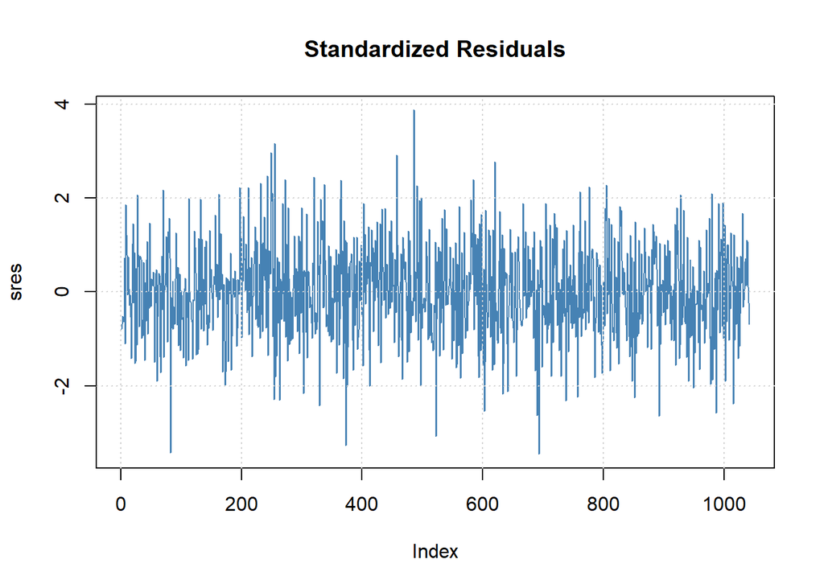

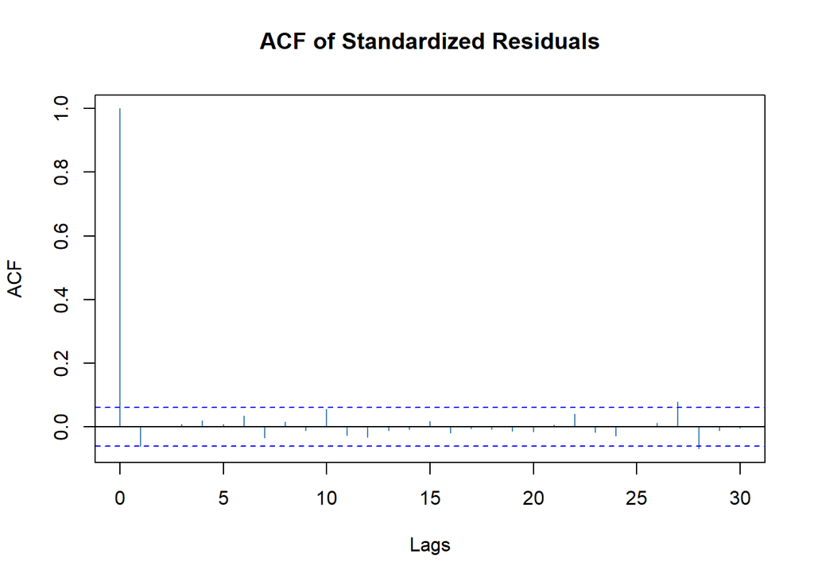

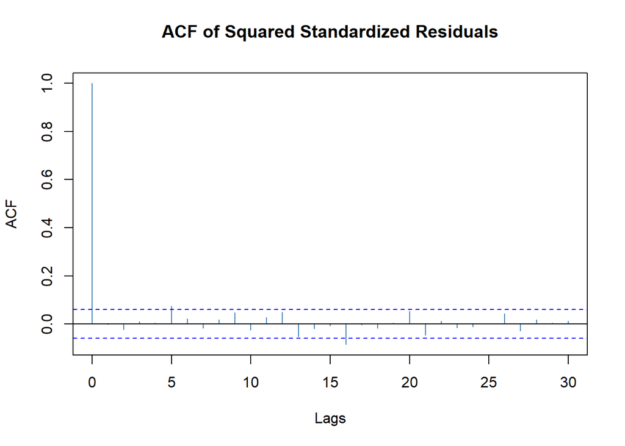

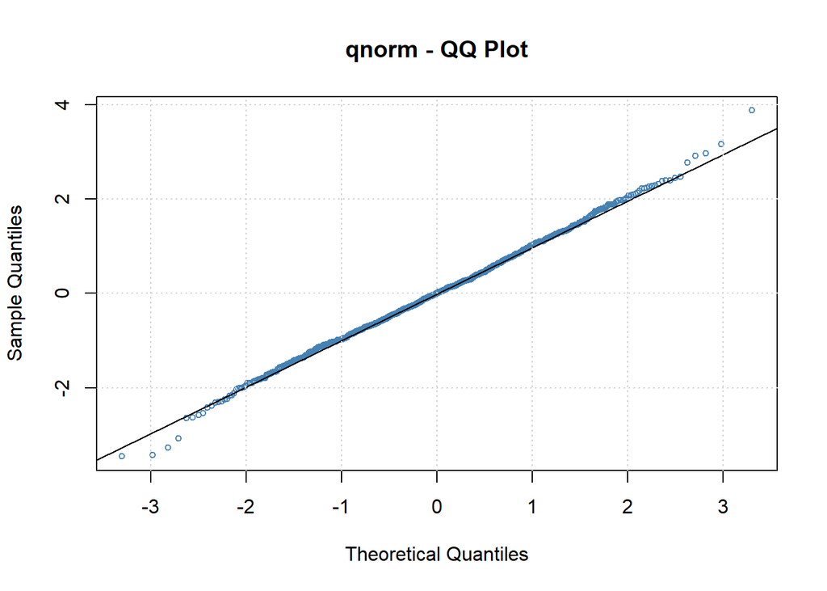

去除有問題的資料區間後，重新抓取2013-10-12到2017-10-12之間的資料，進行對數轉換與差分後配適Garch(1,1)，其殘差一階與二階動差皆無序列相關且從Shapiro-Wilk Test的p-value 來看殘差亦符合常態假設，故若僅用此區間段的資料配適Garch(1,1)是可行的。

## 3.3 S&P500

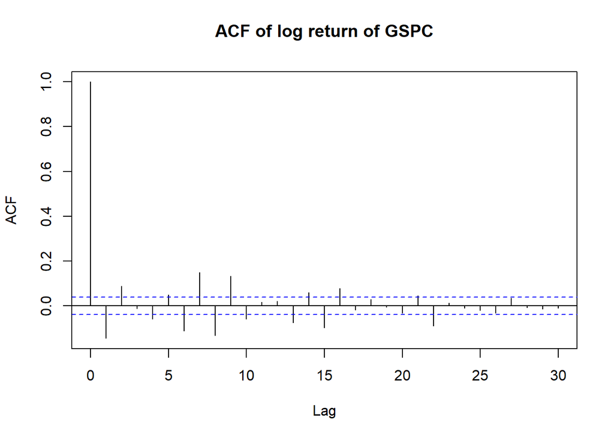

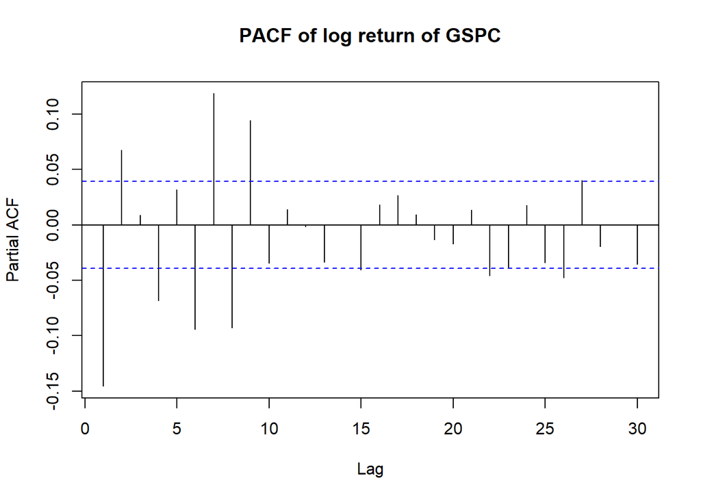

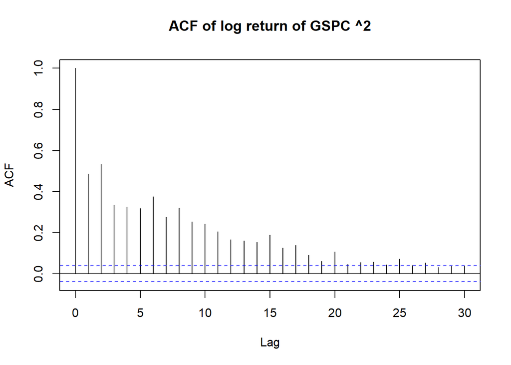

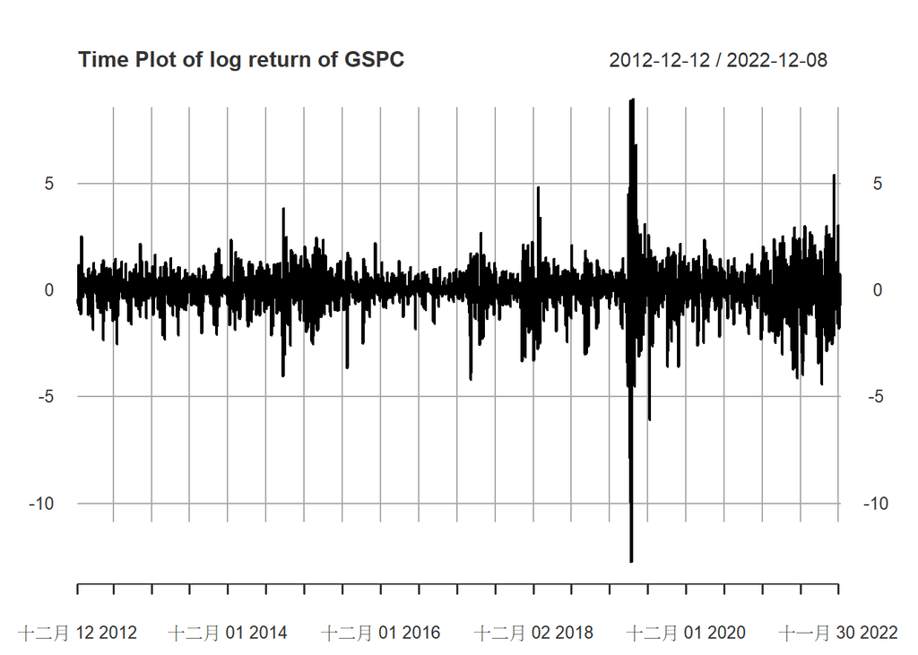

```
##
## Title:
##  Augmented Dickey-Fuller Test
##
## Test Results:
##   PARAMETER:
##     Lag Order: 1
##   STATISTIC:
##     Dickey-Fuller: -35.4503
##   P VALUE:
##     0.01
##
## Description:
##  Mon Jan  2 16:31:17 2023 by user: User
```

```
##
##  Box-Ljung test
##
## data:  logrt.GSPC
## X-squared = 273.01, df = 10, p-value < 2.2e-16
```

```
##
##  Box-Ljung test
##
## data:  logrt.GSPC^2
## X-squared = 3233.6, df = 10, p-value < 2.2e-16
```

資料經過對數轉換與差分過後皆通過ADF Test，但資料的一階動差與二階動差皆有序列相關性故我們選擇ARMA加上Garch建模。

### 3.3.1 Model ARMA(1,1)+Garch(1,1) and residual diagnostic(assume residual form skewed generalized distribution)

```
## $likelihood
## [1] 7501.149 7503.082 7503.089
##
## $order
##      [,1] [,2] [,3]
## [1,]    4    0    4
## [2,]    4    0    5
## [3,]    5    0    4
```

```
##
## Title:
##  GARCH Modelling
##
## Call:
##  garchFit(formula = logrt.GSPC ~ arma(1, 1) + garch(1, 1), data = logrt.GSPC,
##     cond.dist = "sged", trace = F)
##
## Mean and Variance Equation:
##  data ~ arma(1, 1) + garch(1, 1)
## <environment: 0x000001adfde44f10>
##  [data = logrt.GSPC]
##
## Conditional Distribution:
##  sged
##
## Coefficient(s):
##        mu        ar1        ma1      omega     alpha1      beta1       skew
##  0.014324   0.777958  -0.857712   0.023662   0.169401   0.811211   0.818774
##     shape
##  1.366087
##
## Std. Errors:
##  based on Hessian
##
## Error Analysis:
##         Estimate  Std. Error  t value Pr(>|t|)
## mu      0.014324    0.004420    3.241  0.00119 **
## ar1     0.777958    0.066679   11.667  < 2e-16 ***
## ma1    -0.857712    0.054677  -15.687  < 2e-16 ***
## omega   0.023662    0.005182    4.566 4.97e-06 ***
## alpha1  0.169401    0.022450    7.546 4.51e-14 ***
## beta1   0.811211    0.022168   36.593  < 2e-16 ***
## skew    0.818774    0.025329   32.325  < 2e-16 ***
## shape   1.366087    0.052650   25.947  < 2e-16 ***
## ---
## Signif. codes:  0 '***' 0.001 '**' 0.01 '*' 0.05 '.' 0.1 ' ' 1
##
## Log Likelihood:
##  -3036.279    normalized:  -1.206788
##
## Description:
##  Mon Jan  2 16:31:35 2023 by user: User
##
##
## Standardised Residuals Tests:
##                                 Statistic p-Value
##  Jarque-Bera Test   R    Chi^2  1040.569  0
##  Shapiro-Wilk Test  R    W      0.9613904 0
##  Ljung-Box Test     R    Q(10)  26.37937  0.003262099
##  Ljung-Box Test     R    Q(15)  32.6233   0.005290326
##  Ljung-Box Test     R    Q(20)  36.6306   0.01295371
##  Ljung-Box Test     R^2  Q(10)  10.93163  0.3628693
##  Ljung-Box Test     R^2  Q(15)  13.85637  0.5364489
##  Ljung-Box Test     R^2  Q(20)  16.89978  0.6594716
##  LM Arch Test       R    TR^2   12.87548  0.3781558
##
## Information Criterion Statistics:
##      AIC      BIC      SIC     HQIC
## 2.419935 2.438474 2.419915 2.426664
```

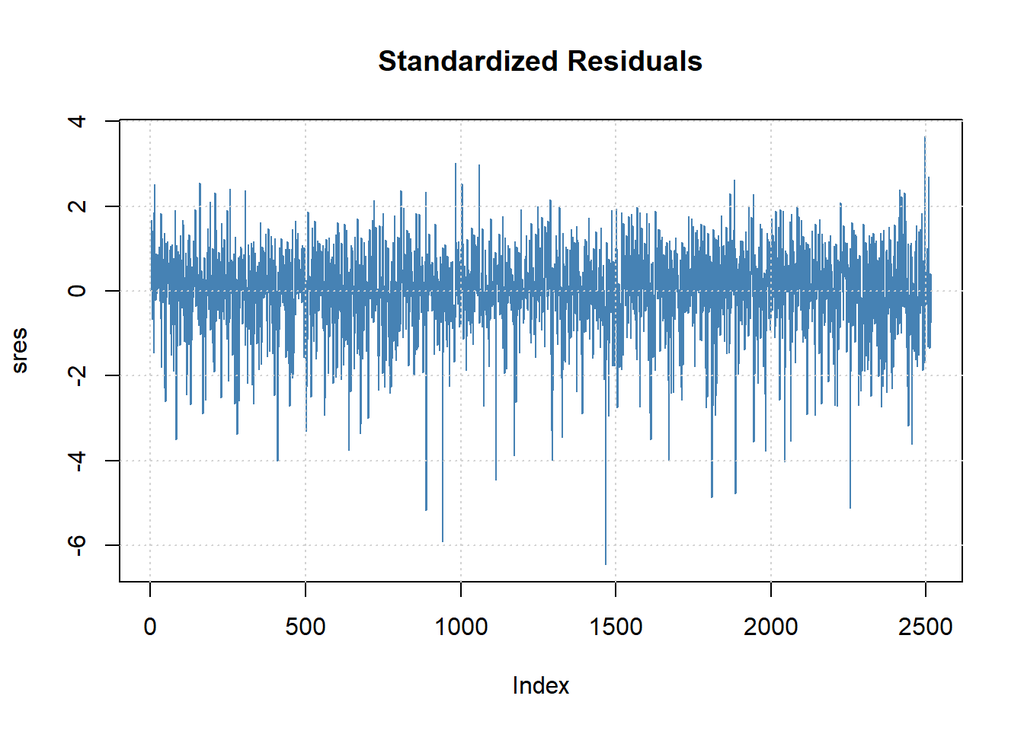

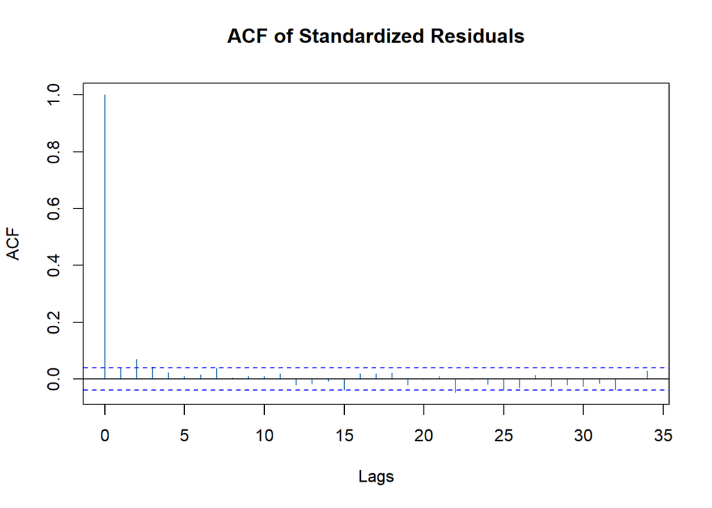

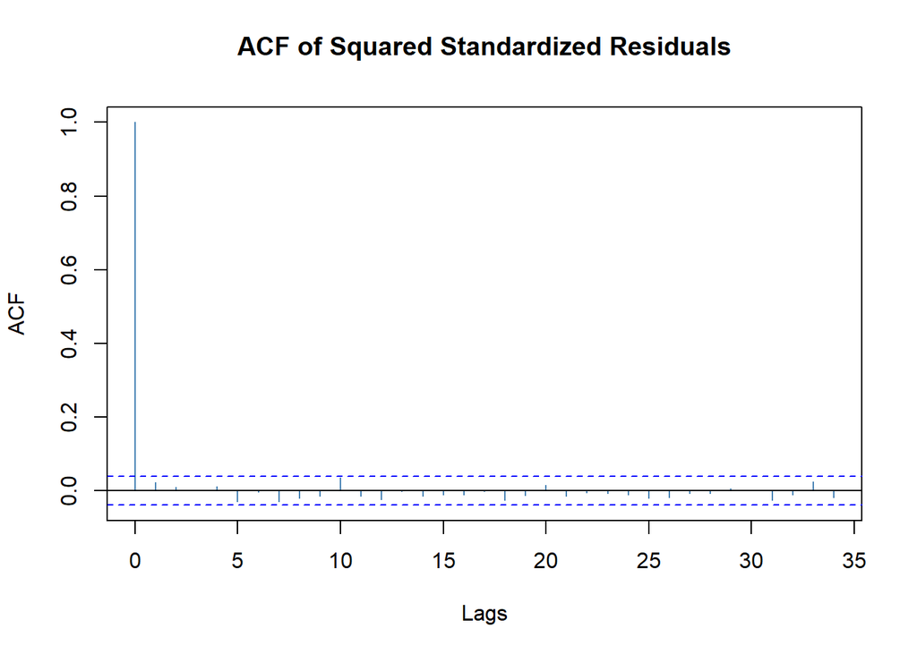

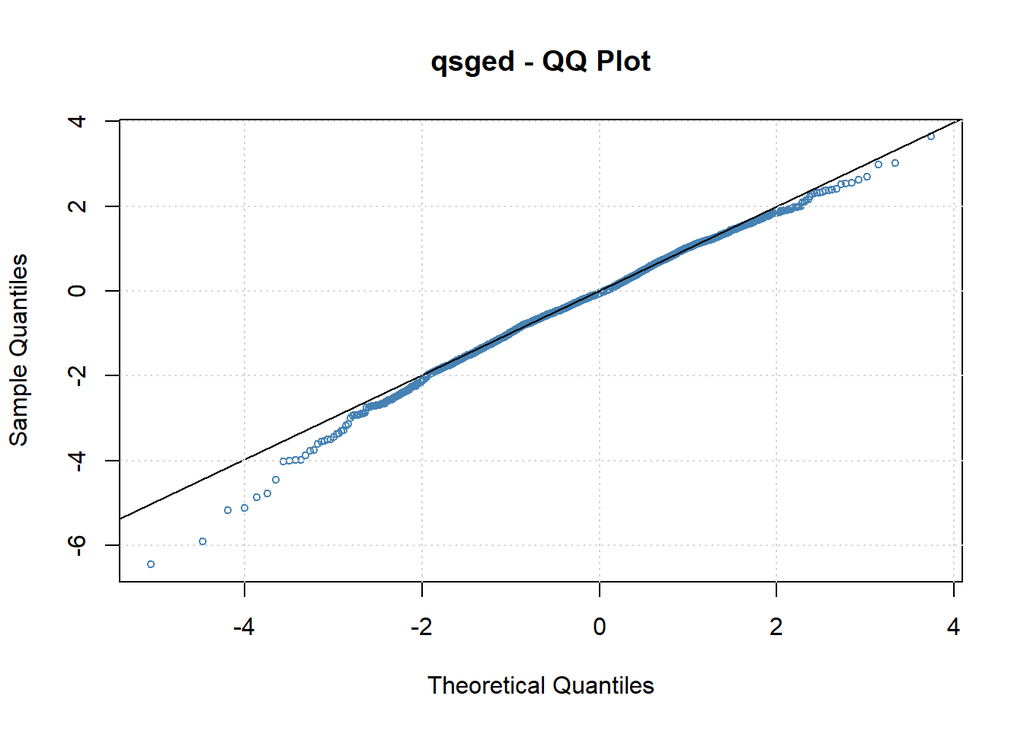

```
##
##  Asymptotic two-sample Kolmogorov-Smirnov test
##
## data:  residuals(fit.GSPC, standardize = T) and rsged(250, nu = 1.332484, xi = 0.868107)
## D = 0.045831, p-value = 0.7259
## alternative hypothesis: two-sided
```

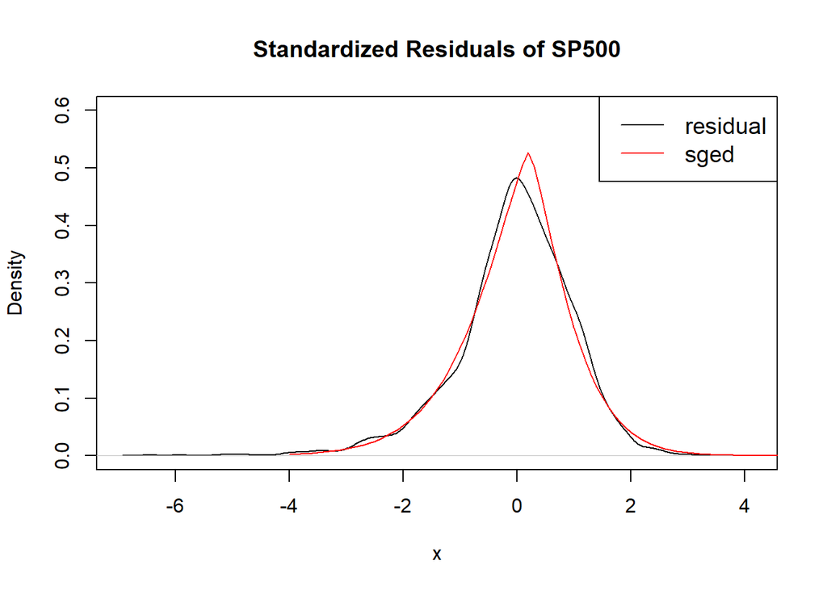

### 3.3.2 KS test for residual

```
##
##  Asymptotic two-sample Kolmogorov-Smirnov test
##
## data:  residuals(fit.GSPC, standardize = T) and rsged(250, nu = 1.332484, xi = 0.868107)
## D = 0.048645, p-value = 0.6549
## alternative hypothesis: two-sided
```

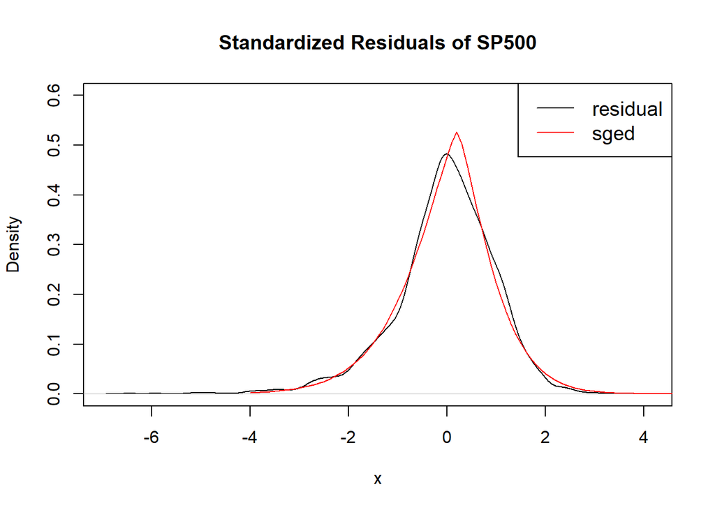

## 3.4 USDJPY

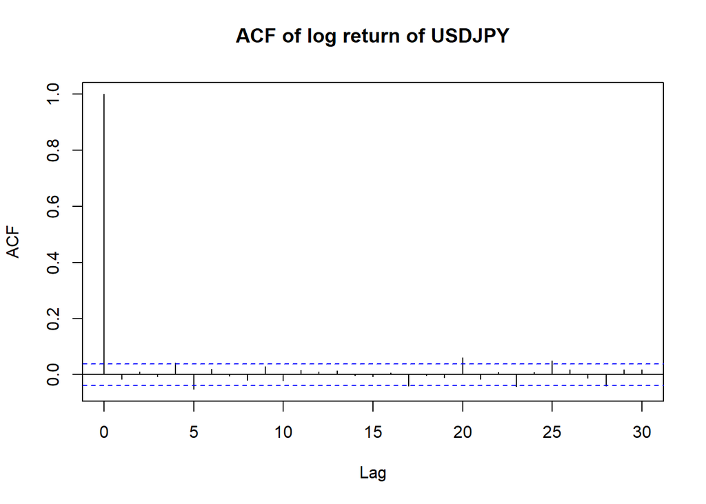

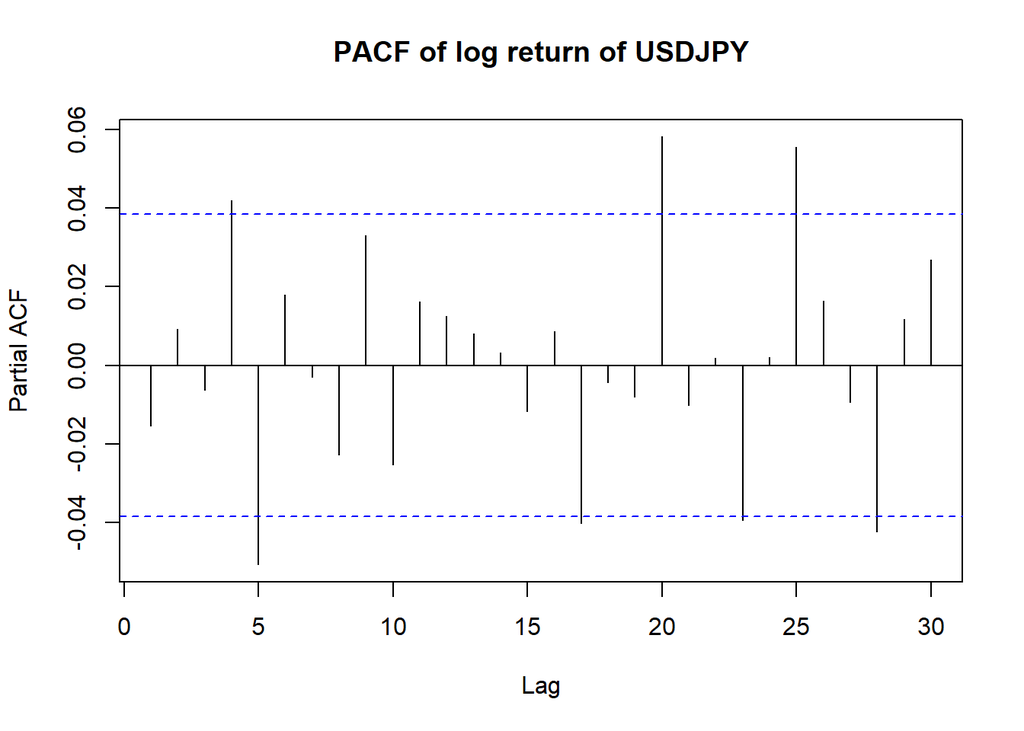

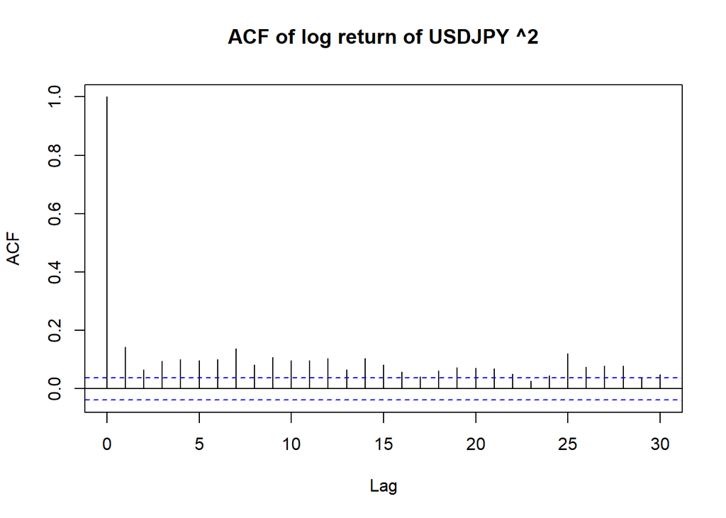

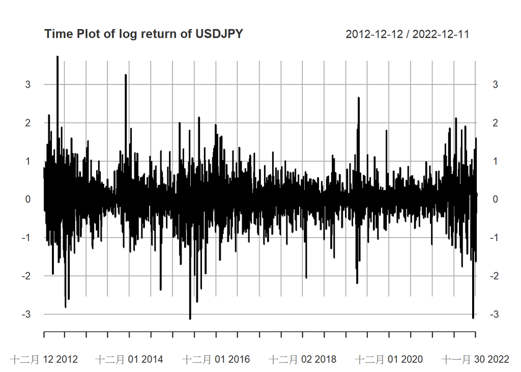

```
##
## Title:
##  Augmented Dickey-Fuller Test
##
## Test Results:
##   PARAMETER:
##     Lag Order: 1
##   STATISTIC:
##     Dickey-Fuller: -36.0209
##   P VALUE:
##     0.01
##
## Description:
##  Mon Jan  2 16:31:36 2023 by user: User
```

```
##
##  Box-Ljung test
##
## data:  logrt.USDJPY
## X-squared = 18.217, df = 10, p-value = 0.05142
```

```
##
##  Box-Ljung test
##
## data:  logrt.USDJPY^2
## X-squared = 288.49, df = 10, p-value < 2.2e-16
```

故我們將先選用ARMA(2,4)與Garch(1,0)配適對數轉換後的資料

### 3.4.1 Model ARMA(1,1)+Garch(1,1) and residual diagnostic(assume residual form skewed T distribution)

我們先選用ARMA(2,4)與Garch(1,0)配適對數轉換後的資料 當係數出現NaN或不顯著，我們便修改模型 arma order 至 (1,1) 而後因 garch effect 為消除完全而將 garch order 至 (1,1)，最後透過K-S test診斷標準化殘差是否符合假設分配，發現標準化殘差服從skewed T distribution。

```
## $likelihood
## [1] 4418.173 4418.221 4418.654
##
## $order
##      [,1] [,2] [,3]
## [1,]    2    0    4
## [2,]    4    0    2
## [3,]    5    0    5
```

```
##
## Title:
##  GARCH Modelling
##
## Call:
##  garchFit(formula = logrt.USDJPY ~ arma(1, 1) + garch(1, 1), data = logrt.USDJPY,
##     cond.dist = "sstd", trace = F)
##
## Mean and Variance Equation:
##  data ~ arma(1, 1) + garch(1, 1)
## <environment: 0x000001adfd9a5460>
##  [data = logrt.USDJPY]
##
## Conditional Distribution:
##  sstd
##
## Coefficient(s):
##         mu         ar1         ma1       omega      alpha1       beta1
##  0.0235343  -0.7745795   0.7445574   0.0031123   0.0736007   0.9201101
##       skew       shape
##  0.9686439   5.9843960
##
## Std. Errors:
##  based on Hessian
##
## Error Analysis:
##         Estimate  Std. Error  t value Pr(>|t|)
## mu      0.023534    0.015364    1.532  0.12559
## ar1    -0.774579    0.101805   -7.608 2.78e-14 ***
## ma1     0.744557    0.106299    7.004 2.48e-12 ***
## omega   0.003112    0.001143    2.722  0.00649 **
## alpha1  0.073601    0.012268    6.000 1.98e-09 ***
## beta1   0.920110    0.012764   72.084  < 2e-16 ***
## skew    0.968644    0.025744   37.625  < 2e-16 ***
## shape   5.984396    0.682057    8.774  < 2e-16 ***
## ---
## Signif. codes:  0 '***' 0.001 '**' 0.01 '*' 0.05 '.' 0.1 ' ' 1
##
## Log Likelihood:
##  -1875.474    normalized:  -0.720228
##
## Description:
##  Mon Jan  2 16:31:51 2023 by user: User
##
##
## Standardised Residuals Tests:
##                                 Statistic p-Value
##  Jarque-Bera Test   R    Chi^2  475.6203  0
##  Shapiro-Wilk Test  R    W      0.9822431 0
##  Ljung-Box Test     R    Q(10)  9.030827  0.5291805
##  Ljung-Box Test     R    Q(15)  11.59159  0.7096422
##  Ljung-Box Test     R    Q(20)  26.64459  0.1455624
##  Ljung-Box Test     R^2  Q(10)  5.972759  0.8175467
##  Ljung-Box Test     R^2  Q(15)  9.785546  0.8330084
##  Ljung-Box Test     R^2  Q(20)  14.56216  0.8008889
##  LM Arch Test       R    TR^2   7.120719  0.8495338
##
## Information Criterion Statistics:
##      AIC      BIC      SIC     HQIC
## 1.446600 1.464618 1.446582 1.453128
```

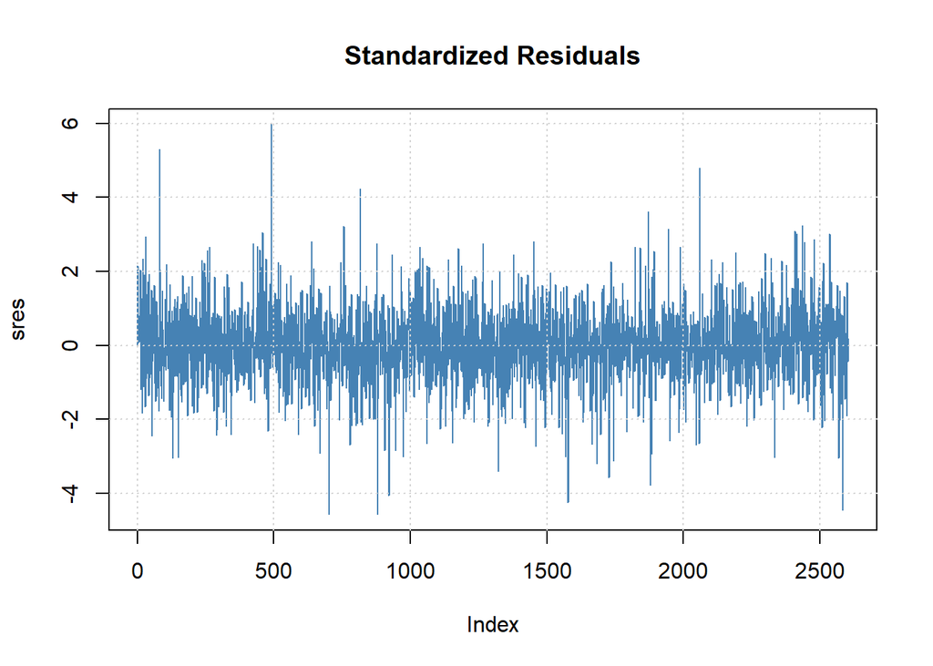

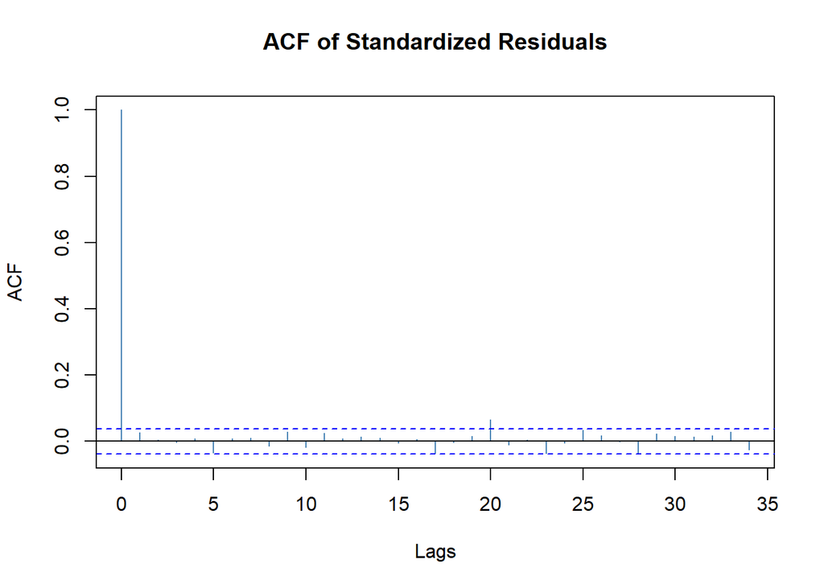

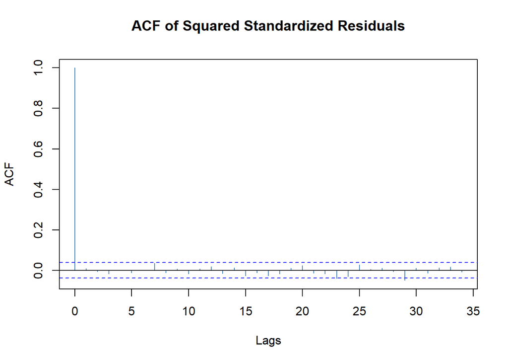

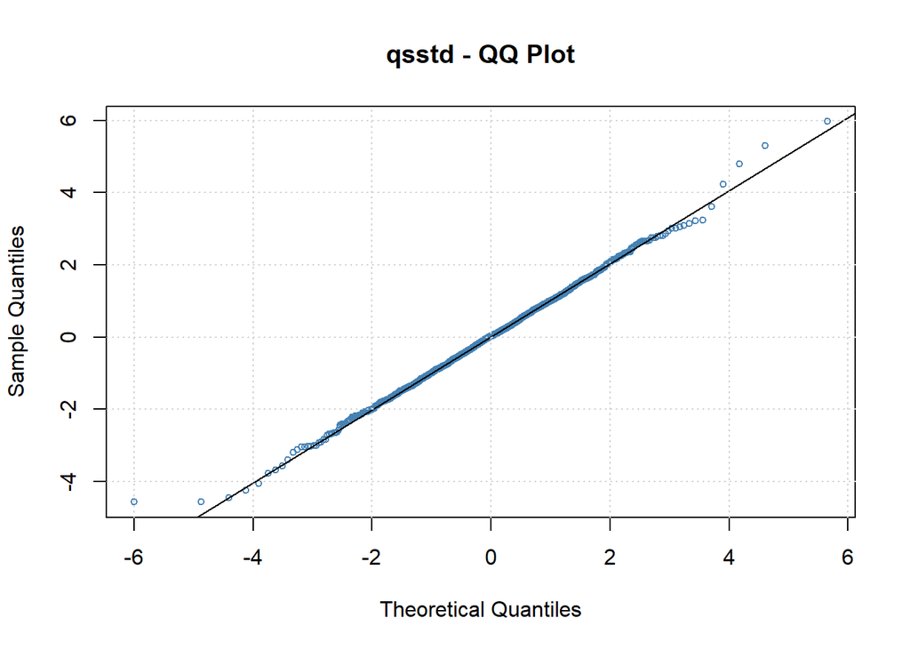

```
##
##  Asymptotic two-sample Kolmogorov-Smirnov test
##
## data:  USJP.resid and rsstd(1000, nu = 5.984396, xi = 0.968644)
## D = 0.021505, p-value = 0.8919
## alternative hypothesis: two-sided
```

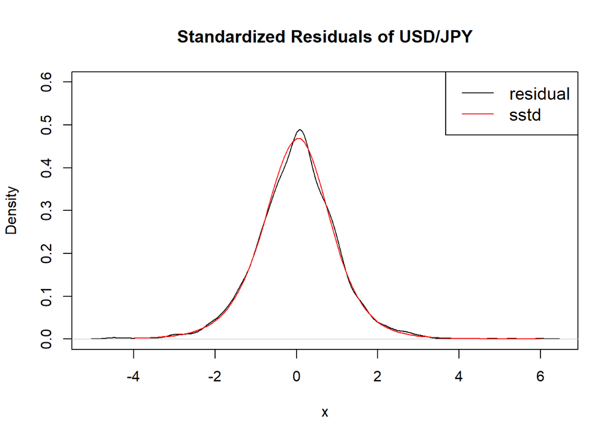